# CIND 820 Big Data Final Project

Jossa Soto

28/03/2022

```r
# Load needed libraries
library(tidyverse)
library(ROSE)
library(tidytext)
library(glue)
library(stringr)
library(ggplot2)
library(patchwork)
library(gt)
library(tm)
library(knitr)
library(NLP)
library(wordcloud)
library(RColorBrewer)
library(rpart)
library(rpart.plot)
library(randomForest)
library(caTools)
library(caret)
library(e1071)
library(MASS)
library(klaR)
library(party)
```

## Dataset

```r
twitter_balanced <- read.csv("Twitter US Airline Sentiment.csv", header = T, na.strings = c("","NA"))

table(twitter_balanced$airline_sentiment)
```

```
##
## negative  neutral positive
##     9178     3099     2363
```

Data is imbalanced so sampling will be done so that the subset is balanced. This will be done by undersampling the negative and neutral group.

```r
twitter_balanced$airline_sentiment <- as.factor(twitter_balanced$airline_sentiment)

twitter_pos_ind <- which(twitter_balanced$airline_sentiment == "positive")
twitter_neg_ind <- which(twitter_balanced$airline_sentiment == "negative")
twitter_neut_ind <- which(twitter_balanced$airline_sentiment == "neutral")

set.seed(2407)
nsample <- 2500
pick_neg <- sample(twitter_neg_ind, nsample)
pick_neut <- sample(twitter_neut_ind, nsample)

twitter_balanced <- twitter_balanced[c(pick_neg, pick_neut, twitter_pos_ind),]

table(twitter_balanced$airline_sentiment)
```

```
##
## negative  neutral positive
##     2500     2500     2363
```

```r
# Declare each variable from df for easy use
tweet_id <- twitter_balanced$tweet_id
airline_sentiment <- twitter_balanced$airline_sentiment
airline_sentiment_confidence <- twitter_balanced$airline_sentiment_confidence
negativereason <- twitter_balanced$negativereason
negativereason_confidence <- twitter_balanced$negativereason_confidence
airline <- twitter_balanced$airline
airline_sentiment_gold <- twitter_balanced$airline_sentiment_gold
name <- twitter_balanced$name
negativereason_gold <- twitter_balanced$negativereason_gold
retweet_count <- twitter_balanced$retweet_count
tweet_text <- twitter_balanced$text
tweet_coord <- twitter_balanced$tweet_coord
tweet_created <- twitter_balanced$tweet_created
tweet_location <- twitter_balanced$tweet_location
user_TZ <- twitter_balanced$user_timezone

# Display first 6 rows of data
head(twitter_balanced)
```

```
##          tweet_id airline_sentiment airline_sentiment_confidence
## 2537  5.69118e+17          negative                            1
## 9481  5.69913e+17          negative                            1
## 6888  5.70059e+17          negative                            1
## 1164  5.69909e+17          negative                            1
## 13197 5.69917e+17          negative                            1
## 9590  5.69860e+17          negative                            1
##                    negativereason negativereason_confidence    airline
## 2537       Customer Service Issue                    1.0000     United
## 9481       Customer Service Issue                    1.0000 US Airways
## 6888                   Can't Tell                    0.6600      Delta
## 1164  Flight Attendant Complaints                    0.3469     United
## 13197 Flight Attendant Complaints                    1.0000   American
## 9590                   Can't Tell                    0.3780 US Airways
##       airline_sentiment_gold            name negativereason_gold retweet_count
```

[output cut: 27 more lines]

## Data Exploration

```r
str(twitter_balanced)
```

```
## 'data.frame':    7363 obs. of  15 variables:
##  $ tweet_id                    : num  5.69e+17 5.70e+17 5.70e+17 5.70e+17 5.70e+17 ...
##  $ airline_sentiment           : Factor w/ 3 levels "negative","neutral",..: 1 1 1 1 1 1 1 1 1 1 ...
##  $ airline_sentiment_confidence: num  1 1 1 1 1 ...
##  $ negativereason              : chr  "Customer Service Issue" "Customer Service Issue" "Can't Tell" "Flight Attendant Complaints" ...
##  $ negativereason_confidence   : num  1 1 0.66 0.347 1 ...
##  $ airline                     : chr  "United" "US Airways" "Delta" "United" ...
##  $ airline_sentiment_gold      : chr  NA NA NA NA ...
##  $ name                        : chr  "BenBell22" "CatieKriewald" "williampseymour" "unvoiced" ...
##  $ negativereason_gold         : chr  NA NA NA NA ...
##  $ retweet_count               : int  0 0 1 0 0 4 0 0 0 0 ...
##  $ text                        : chr  "@united coupled with self-service policies/cost cutting exacerbates the noted issues. (3/3)" "@USAirways called 3x &amp; it says high call volumes call back. At $1 a minute for international calls is there"| __truncated__ "@JetBlue absolutely no worries. I'm…
##  $ tweet_coord                 : chr  NA NA NA NA ...
##  $ tweet_created               : chr  "2015-02-21 4:53" "2015-02-23 9:33" "2015-02-23 19:15" "2015-02-23 9:17" ...
##  $ tweet_location              : chr  NA "Stillwater, MN" NA "Taipei" ...
##  $ user_timezone               : chr  "Eastern Time (US & Canada)" "Central Time (US & Canada)" NA "Taipei" ...
```

```r
# Change airline_sentiment to factors
twitter_balanced$airline <- as.factor(twitter_balanced$airline)
twitter_balanced$airline_sentiment <- as.factor(twitter_balanced$airline_sentiment)
twitter_balanced$airline_sentiment_gold <- as.factor(twitter_balanced$airline_sentiment_gold)
twitter_balanced$negativereason <- as.factor(twitter_balanced$negativereason)
twitter_balanced$negativereason_gold <- as.factor(twitter_balanced$negativereason_gold)

# Change tweet_created from char to date
twitter_balanced$tweet_created <- as.Date(twitter_balanced$tweet_created)

# Rerun str and summary to display updated variables
str(twitter_balanced)
```

```
## 'data.frame':    7363 obs. of  15 variables:
##  $ tweet_id                    : num  5.69e+17 5.70e+17 5.70e+17 5.70e+17 5.70e+17 ...
##  $ airline_sentiment           : Factor w/ 3 levels "negative","neutral",..: 1 1 1 1 1 1 1 1 1 1 ...
##  $ airline_sentiment_confidence: num  1 1 1 1 1 ...
##  $ negativereason              : Factor w/ 10 levels "Bad Flight","Can't Tell",..: 4 4 2 6 6 2 4 7 6 8 ...
##  $ negativereason_confidence   : num  1 1 0.66 0.347 1 ...
##  $ airline                     : Factor w/ 6 levels "American","Delta",..: 4 5 2 4 1 5 1 1 5 1 ...
##  $ airline_sentiment_gold      : Factor w/ 3 levels "negative","neutral",..: NA NA NA NA NA NA NA NA NA NA ...
##  $ name                        : chr  "BenBell22" "CatieKriewald" "williampseymour" "unvoiced" ...
##  $ negativereason_gold         : Factor w/ 5 levels "Can't Tell","Customer Service Issue",..: NA NA NA NA NA NA NA NA NA NA ...
##  $ retweet_count               : int  0 0 1 0 0 4 0 0 0 0 ...
##  $ text                        : chr  "@united coupled with self-service policies/cost cutting exacerbates the noted issues. (3/3)" "@USAirways called 3x &amp; it says high call volumes call back. At $1 a minute for international calls is there"| __truncated__ "@JetBlue absolutely no worries. I'm…
##  $ tweet_coord                 : chr  NA NA NA NA ...
##  $ tweet_created               : Date, format: "2015-02-21" "2015-02-23" ...
##  $ tweet_location              : chr  NA "Stillwater, MN" NA "Taipei" ...
##  $ user_timezone               : chr  "Eastern Time (US & Canada)" "Central Time (US & Canada)" NA "Taipei" ...
```

```r
# Display summary of the twitter_balanced data frame
summary(twitter_balanced)
```

```
##     tweet_id         airline_sentiment airline_sentiment_confidence
##  Min.   :5.676e+17   negative:2500     Min.   :0.3353
##  1st Qu.:5.685e+17   neutral :2500     1st Qu.:0.6777
##  Median :5.693e+17   positive:2363     Median :1.0000
##  Mean   :5.692e+17                     Mean   :0.8768
##  3rd Qu.:5.699e+17                     3rd Qu.:1.0000
##  Max.   :5.703e+17                     Max.   :1.0000
##
##                 negativereason negativereason_confidence           airline
##  Customer Service Issue: 770   Min.   :0.000             American      :1254
##  Late Flight           : 494   1st Qu.:0.000             Delta         :1388
##  Can't Tell            : 329   Median :0.652             Southwest     :1411
##  Cancelled Flight      : 230   Mean   :0.506             United        :1761
##  Lost Luggage          : 197   3rd Qu.:1.000             US Airways    :1210
##  (Other)               : 480   Max.   :1.000             Virgin America: 339
##  NA's                  :4863   NA's   :3737
##  airline_sentiment_gold     name
##  negative:   8          Length:7363
##  neutral :   3          Class :character
##  positive:   5          Mode  :character
##  NA's    :7347
##
##
##
##                     negativereason_gold retweet_count          text
##  Can't Tell                   :   2     Min.   : 0.00000   Length:7363
##  Customer Service Issue       :   3     1st Qu.: 0.00000   Class :character
##  Late Flight                  :   1     Median : 0.00000   Mode  :character
##  Late Flight\nCancelled Flight:   1     Mean   : 0.07307
##  Lost Luggage\nDamaged Luggage:   1     3rd Qu.: 0.00000
##  NA's                         :7355     Max.   :44.00000
##
##  tweet_coord        tweet_created        tweet_location     user_timezone
##  Length:7363        Min.   :2015-02-16   Length:7363        Length:7363
##  Class :character   1st Qu.:2015-02-19   Class :character   Class :character
##  Mode  :character   Median :2015-02-21   Mode  :character   Mode  :character
##                     Mean   :2015-02-20
##                     3rd Qu.:2015-02-23
##                     Max.   :2015-02-24
##
```

```r
# Standard deviation for numerical variables
sd(airline_sentiment_confidence); sd(!is.na(negativereason_confidence)); sd(retweet_count)
```

```
## [1] 0.1745114
```

```
## [1] 0.4999771
```

```
## [1] 0.7609287
```

```r
# Check for and count any NAs
# Unlist to convert the list output to a vector for easier readability
unlist(lapply(lapply(twitter_balanced, is.na), sum))
```

```
##                     tweet_id            airline_sentiment
##                            0                            0
## airline_sentiment_confidence               negativereason
##                            0                         4863
##    negativereason_confidence                      airline
##                         3737                            0
##       airline_sentiment_gold                         name
##                         7347                            0
##          negativereason_gold                retweet_count
##                         7355                            0
##                         text                  tweet_coord
##                            0                         6881
##                tweet_created               tweet_location
##                            0                         2272
##                user_timezone
##                         2338
```

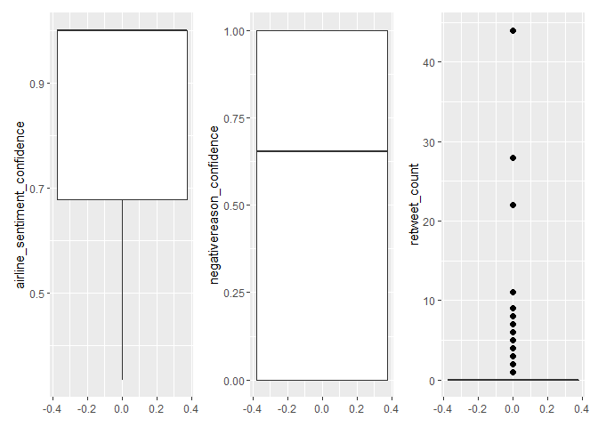

```r
# Check for any outliers in the numerical variables

# Airline sentiment confidence
ASC_box <- twitter_balanced %>% ggplot() +
  geom_boxplot(aes(y = airline_sentiment_confidence), outlier.colour="black", outlier.shape=16, outlier.size=2, notch=FALSE)

# Negative reason confidence
NRC_box <- twitter_balanced %>%
  ggplot() +
  geom_boxplot(aes(y = negativereason_confidence), outlier.colour="black", outlier.shape=16, outlier.size=2, notch=FALSE)

# Retweet count
RC_box <- twitter_balanced %>%
  ggplot() +
  geom_boxplot(aes(y = retweet_count), outlier.colour="black", outlier.shape=16, outlier.size=2, notch=FALSE)

outlier_fig <- ASC_box + NRC_box + RC_box + plot_layout(ncol = 3)
outlier_fig
```

```r
# Frequency of the factor and discrete variables
table(airline)
```

```
## airline
##       American          Delta      Southwest         United     US Airways
##           1254           1388           1411           1761           1210
## Virgin America
##            339
```

```r
table(airline_sentiment)
```

```
## airline_sentiment
## negative  neutral positive
##     2500     2500     2363
```

```r
table(negativereason)
```

```
## negativereason
##                  Bad Flight                  Can't Tell
##                         147                         329
##            Cancelled Flight      Customer Service Issue
##                         230                         770
##             Damaged Luggage Flight Attendant Complaints
##                          15                         128
##     Flight Booking Problems                 Late Flight
##                         147                         494
##                   longlines                Lost Luggage
##                          43                         197
```

```r
table(negativereason_gold)
```

```
## negativereason_gold
##                    Can't Tell        Customer Service Issue
##                             2                             3
##                   Late Flight Late Flight\nCancelled Flight
##                             1                             1
## Lost Luggage\nDamaged Luggage
##                             1
```

```r
table(airline_sentiment_gold)
```

```
## airline_sentiment_gold
## negative  neutral positive
##        8        3        5
```

```r
table(retweet_count)
```

```
## retweet_count
##    0    1    2    3    4    5    6    7    8    9   11   22   28   44
## 7053  246   31   10   11    3    2    1    1    1    1    1    1    1
```

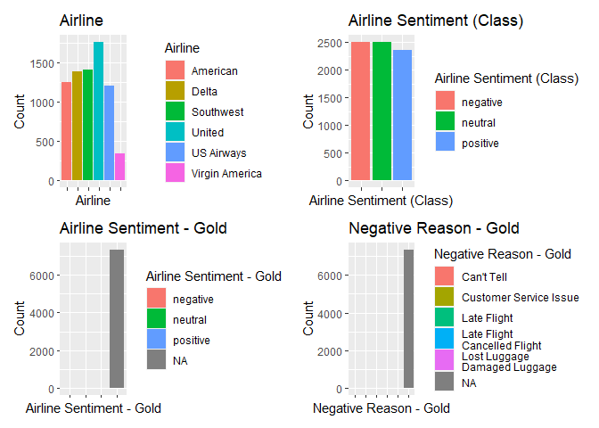

```r
# Airline
airline_bar <- twitter_balanced %>% ggplot() +
  geom_bar(aes(x = airline, fill = airline)) +
  theme(axis.text.x = element_blank()) +
  ggtitle("Airline") + labs(y = "Count", x = "Airline", fill = "Airline")

# Airline sentiment
AS_bar <- twitter_balanced %>% ggplot() +
  geom_bar(aes(x = airline_sentiment, fill = airline_sentiment)) +
  theme(axis.text.x = element_blank()) +
  ggtitle("Airline Sentiment (Class)") + labs(y = "Count", x = "Airline Sentiment (Class)", fill = "Airline Sentiment (Class)")

# Airline sentiment
ASG_bar <- twitter_balanced %>% ggplot() +
  geom_bar(aes(x = airline_sentiment_gold, fill = airline_sentiment_gold)) +
  theme(axis.text.x = element_blank()) +
  ggtitle("Airline Sentiment - Gold") + labs(y = "Count", x = "Airline Sentiment - Gold", fill = "Airline Sentiment - Gold")

# Negative reason
NR_bar <- twitter_balanced %>% ggplot() +
  geom_bar(aes(x = negativereason, fill = negativereason)) +
  theme(axis.text.x = element_blank()) +
  ggtitle("Negative Reason") + labs(y = "Count", x = "Negative Reason", fill = "Negative Reason")

# Negative reason gold
NRG_bar <- twitter_balanced %>% ggplot() +
  geom_bar(aes(x = negativereason_gold, fill = negativereason_gold)) +
  theme(axis.text.x = element_blank()) +
  ggtitle("Negative Reason - Gold") + labs(y = "Count", x = "Negative Reason - Gold", fill = "Negative Reason - Gold")

frequency_fig1 <- airline_bar + AS_bar + ASG_bar + NRG_bar + plot_layout(ncol = 2, nrow = 2)
frequency_fig1
```

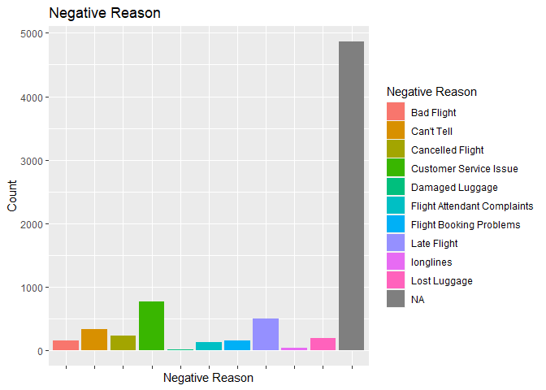

```r
NR_bar
```

## Preprocessing

Before preproccessing, a corpus needs to be created from the “text” variable of the dataset.

```r
tweets_text <- twitter_balanced$text
#tweets_text <- boost_tokenizer(twitter_balanced$text)
str(tweets_text)
```

```
##  chr [1:7363] "@united coupled with self-service policies/cost cutting exacerbates the noted issues. (3/3)" ...
```

```r
# Create a corpus
tweets_source <- VectorSource(tweets_text)

tweets_corpus <- Corpus(tweets_source)

tweets_corpus <- tm_map(tweets_corpus, function(x) iconv(enc2utf8(x), sub = "byte"))
```

Preprocessing is a multi-step process where extraneous elements including punctuation, number, and stop words are removed, and clean the data to minimize the words that could create noise to the data and reduce the model down to the most important words.

```r
tweets_corpus <- tm_map(tweets_corpus, content_transformer(tolower)) # Convert all text to lowercase

tweets_corpus <- tm_map(tweets_corpus, removePunctuation) # Remove all punctuation

tweets_corpus <- tm_map(tweets_corpus, removeNumbers) # Remove numbers

# Custom function to remove extra elements/characters from the text
textprocessing <- function(x){
  gsub("http[[:alnum:]]*",'', x)
  gsub('http\\S+\\s*', '', x) # Remove URLs
  gsub('\\b+RT', '', x) # Remove RT
  gsub('#\\S+', '', x) # Remove Hashtags
  gsub('@\\S+', '', x) # Remove Mentions
  gsub('[[:cntrl:]]', '', x) # Remove Controls and special characters
  gsub("\\d", '', x) # Remove Controls and special characters
  gsub('[[:punct:]]', '', x) # Remove Punctuations
  gsub("^[[:space:]]*","",x) # Remove leading whitespaces
  gsub("[[:space:]]*$","",x) # Remove trailing whitespaces
  gsub(' +',' ',x) # Remove extra whitespaces
}

tweets_corpus <- tm_map(tweets_corpus, textprocessing)

tweets_corpus <- tm_map(tweets_corpus, stripWhitespace) # Remove whitespace

# Create custom list of stop words
stop_words <- c(stopwords("english"), "rt","southwestair", "americanair", "delta", "united", "usairway", "virginamerica", "jetblue", "amp")

tweets_corpus <- tm_map(tweets_corpus, removeWords, stop_words) # Remove stop words

# Create a copy of tweets pre-stemming
tweets_corpus_copy <- tweets_corpus

tweets_corpus <- tm_map(tweets_corpus, stemDocument) # Stem the text

# Display a row of the cleaned corpus
tweets_corpus[[148]][1]
```

```
## $content
## [1] "kudo rsw cs crew rerout pax allevi sale due grade eqp now"
```

## Feature Selection

#### Document-Term: TF-IDF Weights

Create a document-term matrix with TF-IDF weights then reduce the matrix down so it only contains a certain % of the terms.

Weights are calculated using the following formula:

$TF-IDF(t)=TF(t) \times IDF(t)$

$w_{i,j} = tf_{i,j} \times log\frac{N}{df_i}$

```r
tweets_dtm_tfidf <- DocumentTermMatrix(tweets_corpus, control = list(weighting = weightTfIdf))
tweets_dtm_tfidf
```

```
## <<DocumentTermMatrix (documents: 7363, terms: 7942)>>
## Non-/sparse entries: 59135/58417811
## Sparsity           : 100%
## Maximal term length: 352
## Weighting          : term frequency - inverse document frequency (normalized) (tf-idf)
```

```r
tweets_m_tfidf <- as.matrix(tweets_dtm_tfidf)
dim(tweets_m_tfidf)
```

```
## [1] 7363 7942
```

```r
# Display a subset of the matrix
tweets_m_tfidf[14:28, 10:15]
```

```
##     Terms
## Docs       can contact high intern minut say
##   14 0.0000000       0    0      0     0   0
##   15 0.0000000       0    0      0     0   0
##   16 0.0000000       0    0      0     0   0
##   17 0.0000000       0    0      0     0   0
##   18 0.0000000       0    0      0     0   0
##   19 0.0000000       0    0      0     0   0
##   20 0.4671942       0    0      0     0   0
##   21 0.0000000       0    0      0     0   0
##   22 0.0000000       0    0      0     0   0
##   23 0.2669681       0    0      0     0   0
##   24 0.0000000       0    0      0     0   0
##   25 0.0000000       0    0      0     0   0
##   26 0.0000000       0    0      0     0   0
##   27 0.0000000       0    0      0     0   0
##   28 0.0000000       0    0      0     0   0
```

```r
# Reduce the matrix by removing the low frequency terms
tweets_dtm_tfidf_sparse <- removeSparseTerms(tweets_dtm_tfidf, 0.99)
tweets_dtm_tfidf_sparse
```

```
## <<DocumentTermMatrix (documents: 7363, terms: 138)>>
## Non-/sparse entries: 26786/989308
## Sparsity           : 97%
## Maximal term length: 8
## Weighting          : term frequency - inverse document frequency (normalized) (tf-idf)
```

```r
tweets_m_tfidf <- as.matrix(tweets_dtm_tfidf_sparse)
dim(tweets_m_tfidf)
```

```
## [1] 7363  138
```

```r
# Display a subset of the matrix after the low frequency terms were removed
tweets_m_tfidf[14:28, 10:15]
```

```
##     Terms
## Docs even      ever       fli      just never      bag
##   14    0 0.0000000 0.0000000 0.0000000     0 0.000000
##   15    0 0.0000000 0.0000000 0.5670801     0 0.000000
##   16    0 0.0000000 0.0000000 0.0000000     0 0.000000
##   17    0 0.0000000 0.0000000 0.0000000     0 0.000000
##   18    0 0.5612411 0.3933129 0.0000000     0 0.000000
##   19    0 0.0000000 0.0000000 0.3053508     0 0.375852
##   20    0 0.0000000 0.0000000 0.0000000     0 0.000000
##   21    0 0.0000000 0.0000000 0.0000000     0 0.000000
##   22    0 0.0000000 0.0000000 0.0000000     0 0.000000
##   23    0 0.0000000 0.0000000 0.0000000     0 0.000000
##   24    0 0.0000000 0.0000000 0.0000000     0 0.000000
##   25    0 0.0000000 0.0000000 0.0000000     0 0.000000
##   26    0 0.0000000 0.0000000 0.0000000     0 0.000000
##   27    0 0.0000000 0.0000000 0.0000000     0 0.000000
##   28    0 0.0000000 0.0000000 0.0000000     0 0.000000
```

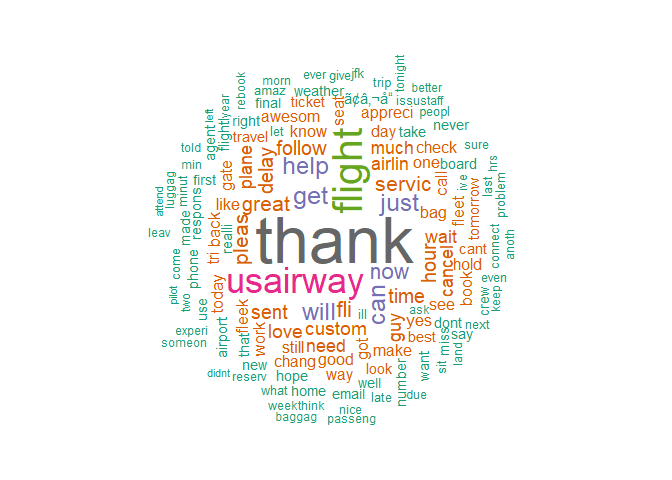

```r
words_tfidf <- sort(colSums(tweets_m_tfidf), decreasing = TRUE)
word_df_tfidf <- data.frame(word = names(words_tfidf), freq = words_tfidf)

wordcloud(words = word_df_tfidf$word, freq = word_df_tfidf$freq, min.freq = 1, max.words = 2000, random.order = FALSE, rot.per = 0.35, colors = brewer.pal(8, "Dark2"))
```

#### Bag of Words

A document-term matrix is created with Bag-of-Words applied. For this model, the corpus is only checked whether the words exist, not where nor the context.

The DTM is also reduced to remove extraneous words.

```r
tweets_dtm_bow <- DocumentTermMatrix(tweets_corpus)
tweets_dtm_bow
```

```
## <<DocumentTermMatrix (documents: 7363, terms: 7942)>>
## Non-/sparse entries: 59135/58417811
## Sparsity           : 100%
## Maximal term length: 352
## Weighting          : term frequency (tf)
```

```r
tweets_m_bow <- as.matrix(tweets_dtm_bow)
dim(tweets_m_bow)
```

```
## [1] 7363 7942
```

```r
# Display a subset of the matrix
tweets_m_bow[14:28, 10:15]
```

```
##     Terms
## Docs can contact high intern minut say
##   14   0       0    0      0     0   0
##   15   0       0    0      0     0   0
##   16   0       0    0      0     0   0
##   17   0       0    0      0     0   0
##   18   0       0    0      0     0   0
##   19   0       0    0      0     0   0
##   20   1       0    0      0     0   0
##   21   0       0    0      0     0   0
##   22   0       0    0      0     0   0
##   23   1       0    0      0     0   0
##   24   0       0    0      0     0   0
##   25   0       0    0      0     0   0
##   26   0       0    0      0     0   0
##   27   0       0    0      0     0   0
##   28   0       0    0      0     0   0
```

```r
# Reduce the matrix by removing the low frequency terms
tweets_dtm_bow_sparse <- removeSparseTerms(tweets_dtm_bow, 0.99)
tweets_dtm_bow_sparse
```

```
## <<DocumentTermMatrix (documents: 7363, terms: 138)>>
## Non-/sparse entries: 26786/989308
## Sparsity           : 97%
## Maximal term length: 8
## Weighting          : term frequency (tf)
```

```r
tweets_m_bow <- as.matrix(tweets_dtm_bow_sparse)
dim(tweets_m_bow)
```

```
## [1] 7363  138
```

```r
# Display a subset of the matrix after the low frequency terms were removed
tweets_m_bow[14:28, 10:15]
```

```
##     Terms
## Docs even ever fli just never bag
##   14    0    0   0    0     0   0
##   15    0    0   0    1     0   0
##   16    0    0   0    0     0   0
##   17    0    0   0    0     0   0
##   18    0    1   1    0     0   0
##   19    0    0   0    1     0   1
##   20    0    0   0    0     0   0
##   21    0    0   0    0     0   0
##   22    0    0   0    0     0   0
##   23    0    0   0    0     0   0
##   24    0    0   0    0     0   0
##   25    0    0   0    0     0   0
##   26    0    0   0    0     0   0
##   27    0    0   0    0     0   0
##   28    0    0   0    0     0   0
```

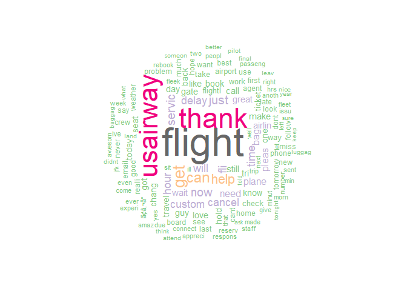

```r
#Word cloud to visually represent the highest frequency terms
words_bow <- sort(colSums(tweets_m_bow), decreasing = TRUE)
word_df_bow <- data.frame(word = names(words_bow), freq = words_bow)

wordcloud(words = word_df_bow$word, freq = word_df_bow$freq, min.freq = 1, max.words = 2000, random.order = FALSE, rot.per = 0.35, colors = brewer.pal(8, "Accent"))
```

#### Unigrams

Unigrams is a one-term version of n-gram model which predicts the occurrence of the words based on the occurrence of its n-1 previous words.

The DTM is also reduced to remove extraneous words.

```r
Unigramtokenizer <- function(x) {
        unlist(lapply(ngrams(words(x), 1), paste, collapse = " "), use.names = FALSE)}
```

```r
# Unigram dtm
tweets_dtm_uni <- DocumentTermMatrix(tweets_corpus,control = list(tokenize = Unigramtokenizer))

tweets_m_uni <- as.matrix(tweets_dtm_uni)
dim(tweets_m_uni)
```

```
## [1] 7363 7942
```

```r
# Display a subset of the matrix
tweets_m_uni[14:28, 10:15]
```

```
##     Terms
## Docs can contact high intern minut say
##   14   0       0    0      0     0   0
##   15   0       0    0      0     0   0
##   16   0       0    0      0     0   0
##   17   0       0    0      0     0   0
##   18   0       0    0      0     0   0
##   19   0       0    0      0     0   0
##   20   1       0    0      0     0   0
##   21   0       0    0      0     0   0
##   22   0       0    0      0     0   0
##   23   1       0    0      0     0   0
##   24   0       0    0      0     0   0
##   25   0       0    0      0     0   0
##   26   0       0    0      0     0   0
##   27   0       0    0      0     0   0
##   28   0       0    0      0     0   0
```

```r
# Reduce the matrix by removing the low frequency terms
tweets_dtm_uni_sparse <- removeSparseTerms(tweets_dtm_uni, 0.99)
tweets_dtm_uni_sparse
```

```
## <<DocumentTermMatrix (documents: 7363, terms: 138)>>
## Non-/sparse entries: 26786/989308
## Sparsity           : 97%
## Maximal term length: 8
## Weighting          : term frequency (tf)
```

```r
tweets_m_uni <- as.matrix(tweets_dtm_uni_sparse)
dim(tweets_m_uni)
```

```
## [1] 7363  138
```

```r
# Display a subset of the matrix after the low frequency terms were removed
tweets_m_uni[14:28, 10:15]
```

```
##     Terms
## Docs even ever fli just never bag
##   14    0    0   0    0     0   0
##   15    0    0   0    1     0   0
##   16    0    0   0    0     0   0
##   17    0    0   0    0     0   0
##   18    0    1   1    0     0   0
##   19    0    0   0    1     0   1
##   20    0    0   0    0     0   0
##   21    0    0   0    0     0   0
##   22    0    0   0    0     0   0
##   23    0    0   0    0     0   0
##   24    0    0   0    0     0   0
##   25    0    0   0    0     0   0
##   26    0    0   0    0     0   0
##   27    0    0   0    0     0   0
##   28    0    0   0    0     0   0
```

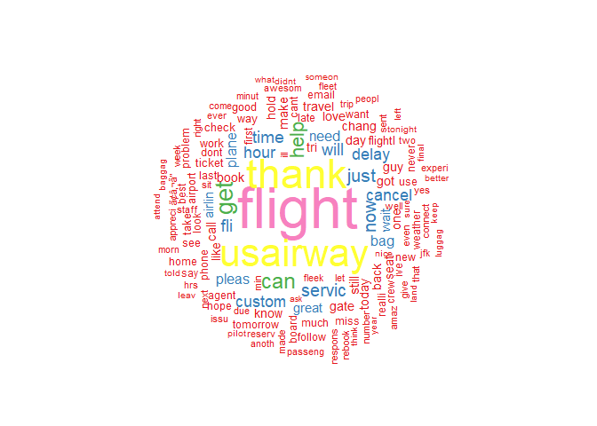

```r
words_uni <- sort(colSums(tweets_m_uni), decreasing = TRUE)
word_df_uni <- data.frame(word = names(words_uni), freq = words_uni)

wordcloud(words = word_df_uni$word, freq = word_df_uni$freq, min.freq = 1, max.words = 2000, random.order = FALSE, rot.per = 0.35, colors = brewer.pal(8, "Set1"))
```

## Classifier

### Decision Tree

Apply the Decision Tree algorithm to the three models: TF-IDF, Bag-of-Words, and Unigram.

#### TF-IDF

```r
m_tfidf <- as.data.frame(tweets_m_tfidf)
colnames(m_tfidf) <- make.names(colnames(m_tfidf))
m_tfidf$class = twitter_balanced$airline_sentiment
```

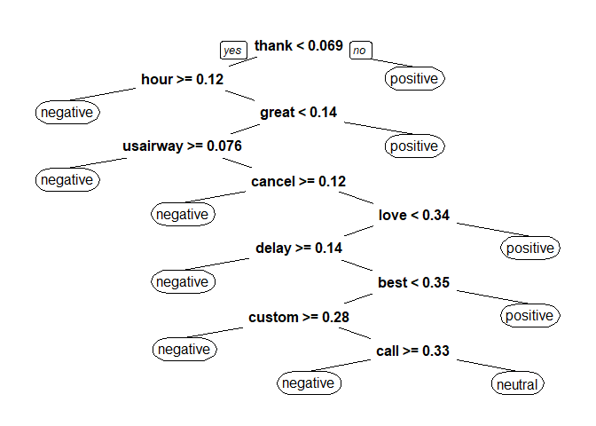

```r
set.seed(439)
split_tfidf = sample.split(m_tfidf$class, SplitRatio = 0.7)
train_tfidf = subset(m_tfidf, split_tfidf == TRUE)
test_tfidf = subset(m_tfidf, split_tfidf == FALSE)

DT_model_tfidf <- rpart(class~., data = train_tfidf, method = "class")

predictDT_tfidf <- predict(DT_model_tfidf, newdata = test_tfidf, type = "class")

prp(DT_model_tfidf) #tree visualization
```

```r
printcp(DT_model_tfidf)
```

```
##
## Classification tree:
## rpart(formula = class ~ ., data = train_tfidf, method = "class")
##
## Variables actually used in tree construction:
##  [1] best     call     cancel   custom   delay    great    hour     love
##  [9] thank    usairway
##
## Root node error: 3404/5154 = 0.66046
##
## n= 5154
##
##         CP nsplit rel error  xerror     xstd
## 1 0.190952      0   1.00000 1.02321 0.009872
## 2 0.037799      1   0.80905 0.80905 0.010520
## 3 0.024089      4   0.69565 0.69683 0.010512
## 4 0.016451      5   0.67156 0.68566 0.010498
## 5 0.013220      7   0.63866 0.64806 0.010435
## 6 0.010870      9   0.61222 0.62103 0.010374
## 7 0.010000     10   0.60135 0.60752 0.010337
```

```r
cf_DT_tfidf_loo <- confusionMatrix(table(test_tfidf$class, predictDT_tfidf)) #evaluation of confusion matrix

cf_DT_tfidf_loo
```

```
## Confusion Matrix and Statistics
##
##           predictDT_tfidf
##            negative neutral positive
##   negative      362     349       39
##   neutral       148     543       59
##   positive       62     241      406
##
## Overall Statistics
##
##                Accuracy : 0.5935
##                  95% CI : (0.5727, 0.6141)
##     No Information Rate : 0.5129
##     P-Value [Acc > NIR] : 1.698e-14
##
##                   Kappa : 0.3884
##
##  Mcnemar's Test P-Value : < 2.2e-16
##
## Statistics by Class:
##
##                      Class: negative Class: neutral Class: positive
## Sensitivity                   0.6329         0.4793          0.8056
## Specificity                   0.7630         0.8076          0.8223
## Pos Pred Value                0.4827         0.7240          0.5726
## Neg Pred Value                0.8561         0.5956          0.9347
## Prevalence                    0.2589         0.5129          0.2282
## Detection Rate                0.1639         0.2458          0.1838
## Detection Prevalence          0.3395         0.3395          0.3210
## Balanced Accuracy             0.6979         0.6434          0.8139
```

Second attempt (5-fold validation)

```r
set.seed(901)
model_DT_tfidf_5 <- train(
  m_tfidf[,!names(m_tfidf) %in% c("class")], m_tfidf$class, "rpart",
  trControl = trainControl(method = "cv", number = 5, savePredictions = "final", classProbs = TRUE)
)

model_DT_tfidf_5
```

```
## CART
##
## 7363 samples
##  138 predictor
##    3 classes: 'negative', 'neutral', 'positive'
##
## No pre-processing
## Resampling: Cross-Validated (5 fold)
## Summary of sample sizes: 5891, 5890, 5890, 5890, 5891
## Resampling results across tuning parameters:
##
##   cp          Accuracy   Kappa
##   0.03050243  0.5126932  0.26611135
##   0.04009870  0.4801066  0.21677540
##   0.19206251  0.3874820  0.07419039
##
## Accuracy was used to select the optimal model using the largest value.
## The final value used for the model was cp = 0.03050243.
```

```r
#create a confusion matrix for the best fold
cf_DT_tfidf_5 <- confusionMatrix(model_DT_tfidf_5$pred[order(model_DT_tfidf_5$pred$rowIndex),2], m_tfidf$class)

cf_DT_tfidf_5
```

```
## Confusion Matrix and Statistics
##
##           Reference
## Prediction negative neutral positive
##   negative      489     136       63
##   neutral      1899    2175     1189
##   positive      112     189     1111
##
## Overall Statistics
##
##                Accuracy : 0.5127
##                  95% CI : (0.5012, 0.5242)
##     No Information Rate : 0.3395
##     P-Value [Acc > NIR] : < 2.2e-16
##
##                   Kappa : 0.2661
##
##  Mcnemar's Test P-Value : < 2.2e-16
##
## Statistics by Class:
##
##                      Class: negative Class: neutral Class: positive
## Sensitivity                  0.19560         0.8700          0.4702
## Specificity                  0.95908         0.3650          0.9398
## Pos Pred Value               0.71076         0.4133          0.7868
## Neg Pred Value               0.69873         0.8452          0.7896
## Prevalence                   0.33954         0.3395          0.3209
## Detection Rate               0.06641         0.2954          0.1509
## Detection Prevalence         0.09344         0.7148          0.1918
## Balanced Accuracy            0.57734         0.6175          0.7050
```

```r
#display the accuracies of each individual fold
pred_DT_tfidf_5 <- model_DT_tfidf_5$pred
pred_DT_tfidf_5$equal <- ifelse(pred_DT_tfidf_5$pred == pred_DT_tfidf_5$obs, 1, 0)

eachfold_DT_tfidf_5 <- pred_DT_tfidf_5 %>%
  group_by(Resample) %>%
  summarise_at(vars(equal),
               list(Accuracy = mean))

eachfold_DT_tfidf_5
```

```
## # A tibble: 5 x 2
##   Resample Accuracy
##   <chr>       <dbl>
## 1 Fold1       0.488
## 2 Fold2       0.526
## 3 Fold3       0.553
## 4 Fold4       0.499
## 5 Fold5       0.497
```

Third attempt (10-fold validation)

```r
set.seed(902)
model_DT_tfidf <- train(
  m_tfidf[,!names(m_tfidf) %in% c("class")], m_tfidf$class, "rpart",
  trControl = trainControl(method = "cv", number = 10, savePredictions = "final", classProbs = TRUE)
)

model_DT_tfidf
```

```
## CART
##
## 7363 samples
##  138 predictor
##    3 classes: 'negative', 'neutral', 'positive'
##
## No pre-processing
## Resampling: Cross-Validated (10 fold)
## Summary of sample sizes: 6627, 6627, 6627, 6627, 6627, 6627, ...
## Resampling results across tuning parameters:
##
##   cp          Accuracy   Kappa
##   0.03050243  0.5264205  0.28705479
##   0.04009870  0.4737176  0.20715054
##   0.19206251  0.3862748  0.07242927
##
## Accuracy was used to select the optimal model using the largest value.
## The final value used for the model was cp = 0.03050243.
```

```r
#create a confusion matrix for the best fold
cf_DT_tfidf <- confusionMatrix(model_DT_tfidf$pred[order(model_DT_tfidf$pred$rowIndex),2], m_tfidf$class)

cf_DT_tfidf
```

```
## Confusion Matrix and Statistics
##
##           Reference
## Prediction negative neutral positive
##   negative      584     196       79
##   neutral      1799    2103     1095
##   positive      117     201     1189
##
## Overall Statistics
##
##                Accuracy : 0.5264
##                  95% CI : (0.5149, 0.5379)
##     No Information Rate : 0.3395
##     P-Value [Acc > NIR] : < 2.2e-16
##
##                   Kappa : 0.2871
##
##  Mcnemar's Test P-Value : < 2.2e-16
##
## Statistics by Class:
##
##                      Class: negative Class: neutral Class: positive
## Sensitivity                  0.23360         0.8412          0.5032
## Specificity                  0.94345         0.4049          0.9364
## Pos Pred Value               0.67986         0.4209          0.7890
## Neg Pred Value               0.70541         0.8322          0.7995
## Prevalence                   0.33954         0.3395          0.3209
## Detection Rate               0.07932         0.2856          0.1615
## Detection Prevalence         0.11666         0.6787          0.2047
## Balanced Accuracy            0.58853         0.6230          0.7198
```

```r
pred_DT_tfidf <- model_DT_tfidf$pred
pred_DT_tfidf$equal <- ifelse(pred_DT_tfidf$pred == pred_DT_tfidf$obs, 1, 0)

eachfold_DT_tfidf <- pred_DT_tfidf %>%
  group_by(Resample) %>%
  summarise_at(vars(equal),
               list(Accuracy = mean))

eachfold_DT_tfidf
```

```
## # A tibble: 10 x 2
##    Resample Accuracy
##    <chr>       <dbl>
##  1 Fold01      0.490
##  2 Fold02      0.537
##  3 Fold03      0.537
##  4 Fold04      0.572
##  5 Fold05      0.496
##  6 Fold06      0.552
##  7 Fold07      0.535
##  8 Fold08      0.499
##  9 Fold09      0.503
## 10 Fold10      0.543
```

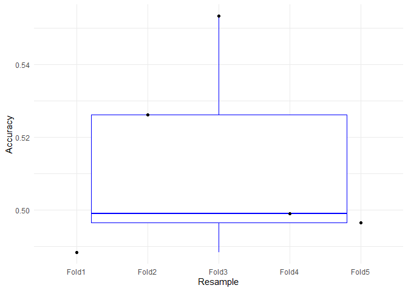

```r
#visualize accuracy scores
ggplot(data=eachfold_DT_tfidf_5, aes(x=Resample, y=Accuracy, group=1)) +
geom_boxplot(color="blue") +
geom_point() +
theme_minimal()
```

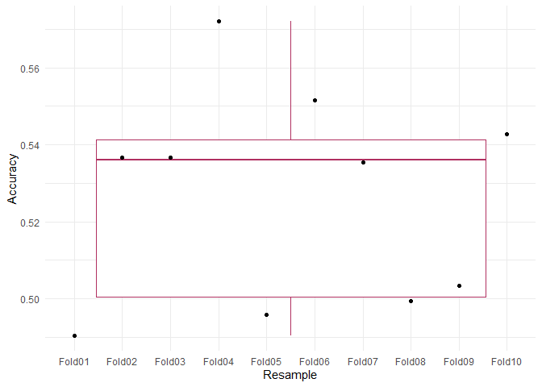

```r
#visualize accuracy scores
ggplot(data=eachfold_DT_tfidf, aes(x=Resample, y=Accuracy, group=1)) +
geom_boxplot(color="maroon") +
geom_point() +
theme_minimal()
```

#### Bag-of-Words

```r
m_bow <- as.data.frame(tweets_m_bow)
colnames(m_bow) <- make.names(colnames(m_bow))
m_bow$class = twitter_balanced$airline_sentiment
```

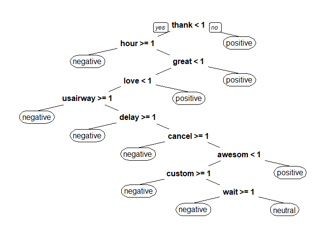

```r
set.seed(989)
split_bow = sample.split(m_bow$class, SplitRatio = 0.7)
train_bow = subset(m_bow, split_bow == TRUE)
test_bow = subset(m_bow, split_bow == FALSE)

DT_model_bow <- rpart(class~., data = train_bow)

predictDT_bow <- predict(DT_model_bow, newdata = test_bow, type = "class")

prp(DT_model_bow) #tree visualization
```

```r
cf_DT_bow_loo <- confusionMatrix(table(test_bow$class, predictDT_bow)) #evaluation of confusion matrix

cf_DT_bow_loo
```

```
## Confusion Matrix and Statistics
##
##           predictDT_bow
##            negative neutral positive
##   negative      386     328       36
##   neutral       140     538       72
##   positive       71     267      371
##
## Overall Statistics
##
##                Accuracy : 0.5862
##                  95% CI : (0.5654, 0.6069)
##     No Information Rate : 0.5129
##     P-Value [Acc > NIR] : 2.687e-12
##
##                   Kappa : 0.3773
##
##  Mcnemar's Test P-Value : < 2.2e-16
##
## Statistics by Class:
##
##                      Class: negative Class: neutral Class: positive
## Sensitivity                   0.6466         0.4748          0.7745
## Specificity                   0.7742         0.8030          0.8046
## Pos Pred Value                0.5147         0.7173          0.5233
## Neg Pred Value                0.8554         0.5922          0.9280
## Prevalence                    0.2703         0.5129          0.2168
## Detection Rate                0.1747         0.2435          0.1679
## Detection Prevalence          0.3395         0.3395          0.3210
## Balanced Accuracy             0.7104         0.6389          0.7896
```

Second attempt (5-fold validation)

```r
set.seed(801)
model_DT_bow_5 <- train(
  m_bow[,!names(m_bow) %in% c("class")], m_bow$class, "rpart",
  trControl = trainControl(method = "cv", number = 5, savePredictions = "final", classProbs = TRUE)
)

model_DT_bow_5
```

```
## CART
##
## 7363 samples
##  138 predictor
##    3 classes: 'negative', 'neutral', 'positive'
##
## No pre-processing
## Resampling: Cross-Validated (5 fold)
## Summary of sample sizes: 5890, 5891, 5891, 5890, 5890
## Resampling results across tuning parameters:
##
##   cp          Accuracy   Kappa
##   0.03057098  0.5256056  0.28583677
##   0.04009870  0.4739917  0.20756635
##   0.19206251  0.3881605  0.07521317
##
## Accuracy was used to select the optimal model using the largest value.
## The final value used for the model was cp = 0.03057098.
```

```r
#create a confusion matrix for the best fold
cf_DT_bow_5 <- confusionMatrix(model_DT_bow_5$pred[order(model_DT_bow_5$pred$rowIndex),2], m_bow$class)

cf_DT_bow_5
```

```
## Confusion Matrix and Statistics
##
##           Reference
## Prediction negative neutral positive
##   negative      599     205       76
##   neutral      1784    2086     1102
##   positive      117     209     1185
##
## Overall Statistics
##
##                Accuracy : 0.5256
##                  95% CI : (0.5141, 0.5371)
##     No Information Rate : 0.3395
##     P-Value [Acc > NIR] : < 2.2e-16
##
##                   Kappa : 0.2858
##
##  Mcnemar's Test P-Value : < 2.2e-16
##
## Statistics by Class:
##
##                      Class: negative Class: neutral Class: positive
## Sensitivity                  0.23960         0.8344          0.5015
## Specificity                  0.94222         0.4065          0.9348
## Pos Pred Value               0.68068         0.4195          0.7842
## Neg Pred Value               0.70677         0.8269          0.7987
## Prevalence                   0.33954         0.3395          0.3209
## Detection Rate               0.08135         0.2833          0.1609
## Detection Prevalence         0.11952         0.6753          0.2052
## Balanced Accuracy            0.59091         0.6205          0.7181
```

```r
pred_DT_bow_5 <- model_DT_bow_5$pred
pred_DT_bow_5$equal <- ifelse(pred_DT_bow_5$pred == pred_DT_bow_5$obs, 1, 0)

eachfold_DT_bow_5 <- pred_DT_bow_5 %>%
  group_by(Resample) %>%
  summarise_at(vars(equal),
               list(Accuracy = mean))

eachfold_DT_bow_5
```

```
## # A tibble: 5 x 2
##   Resample Accuracy
##   <chr>       <dbl>
## 1 Fold1       0.553
## 2 Fold2       0.545
## 3 Fold3       0.540
## 4 Fold4       0.511
## 5 Fold5       0.479
```

Third attempt (10-fold validation)

```r
set.seed(802)
model_DT_bow <- train(
  m_bow[,!names(m_bow) %in% c("class")], m_bow$class, "rpart",
  trControl = trainControl(method = "cv", number = 10, savePredictions = "final", classProbs = TRUE)
)

model_DT_bow
```

```
## CART
##
## 7363 samples
##  138 predictor
##    3 classes: 'negative', 'neutral', 'positive'
##
## No pre-processing
## Resampling: Cross-Validated (10 fold)
## Summary of sample sizes: 6627, 6627, 6626, 6626, 6627, 6627, ...
## Resampling results across tuning parameters:
##
##   cp          Accuracy   Kappa
##   0.03057098  0.5179923  0.27423535
##   0.04009870  0.4784731  0.21431495
##   0.19206251  0.3997096  0.09316558
##
## Accuracy was used to select the optimal model using the largest value.
## The final value used for the model was cp = 0.03057098.
```

```r
#create a confusion matrix for the best fold
cf_DT_bow <- confusionMatrix(model_DT_bow$pred[order(model_DT_bow$pred$rowIndex),2], m_bow$class)

cf_DT_bow
```

```
## Confusion Matrix and Statistics
##
##           Reference
## Prediction negative neutral positive
##   negative      527     169       67
##   neutral      1860    2133     1142
##   positive      113     198     1154
##
## Overall Statistics
##
##                Accuracy : 0.518
##                  95% CI : (0.5065, 0.5295)
##     No Information Rate : 0.3395
##     P-Value [Acc > NIR] : < 2.2e-16
##
##                   Kappa : 0.2743
##
##  Mcnemar's Test P-Value : < 2.2e-16
##
## Statistics by Class:
##
##                      Class: negative Class: neutral Class: positive
## Sensitivity                  0.21080         0.8532          0.4884
## Specificity                  0.95147         0.3827          0.9378
## Pos Pred Value               0.69069         0.4154          0.7877
## Neg Pred Value               0.70106         0.8353          0.7950
## Prevalence                   0.33954         0.3395          0.3209
## Detection Rate               0.07157         0.2897          0.1567
## Detection Prevalence         0.10363         0.6974          0.1990
## Balanced Accuracy            0.58114         0.6179          0.7131
```

```r
pred_DT_bow <- model_DT_bow$pred
pred_DT_bow$equal <- ifelse(pred_DT_bow$pred == pred_DT_bow$obs, 1, 0)

eachfold_DT_bow <- pred_DT_bow %>%
  group_by(Resample) %>%
  summarise_at(vars(equal),
               list(Accuracy = mean))

eachfold_DT_bow
```

```
## # A tibble: 10 x 2
##    Resample Accuracy
##    <chr>       <dbl>
##  1 Fold01      0.537
##  2 Fold02      0.477
##  3 Fold03      0.543
##  4 Fold04      0.483
##  5 Fold05      0.486
##  6 Fold06      0.488
##  7 Fold07      0.551
##  8 Fold08      0.565
##  9 Fold09      0.564
## 10 Fold10      0.486
```

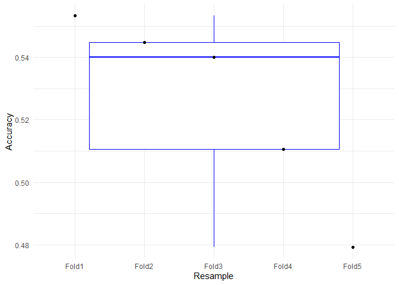

```r
#visualize accuracy scores
ggplot(data=eachfold_DT_bow_5, aes(x=Resample, y=Accuracy, group=1)) +
geom_boxplot(color="blue") +
geom_point() +
theme_minimal()
```

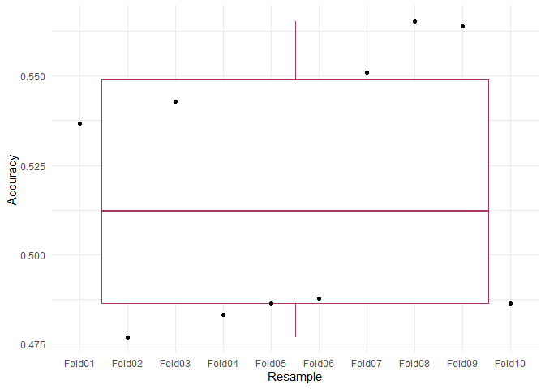

```r
#visualize accuracy scores
ggplot(data=eachfold_DT_bow, aes(x=Resample, y=Accuracy, group=1)) +
geom_boxplot(color="maroon") +
geom_point() +
theme_minimal()
```

#### Unigram

```r
m_uni <- as.data.frame(tweets_m_uni)
colnames(m_uni) <- make.names(colnames(m_uni))
m_uni$class = twitter_balanced$airline_sentiment
```

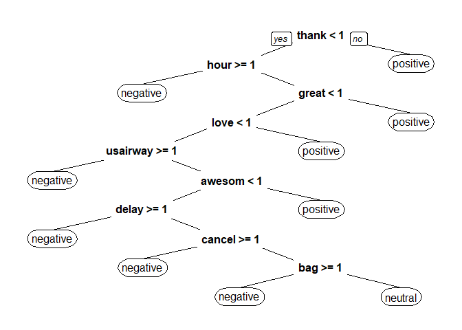

```r
set.seed(825)
split_uni = sample.split(m_uni$class, SplitRatio = 0.7)
train_uni = subset(m_uni, split_uni == TRUE)
test_uni = subset(m_uni, split_uni == FALSE)

DT_model_uni <- rpart(class~., data = train_uni)

predictDT_uni <- predict(DT_model_uni, newdata = test_uni, type = "class")

prp(DT_model_uni, yesno = TRUE) #tree visualization
```

```r
cf_DT_uni_loo <- confusionMatrix(table(test_uni$class, predictDT_uni)) #evaluation of confusion matrix

cf_DT_uni_loo
```

```
## Confusion Matrix and Statistics
##
##           predictDT_uni
##            negative neutral positive
##   negative      338     360       52
##   neutral       120     564       66
##   positive       51     274      384
##
## Overall Statistics
##
##                Accuracy : 0.5822
##                  95% CI : (0.5613, 0.6028)
##     No Information Rate : 0.5423
##     P-Value [Acc > NIR] : 8.965e-05
##
##                   Kappa : 0.3714
##
##  Mcnemar's Test P-Value : < 2.2e-16
##
## Statistics by Class:
##
##                      Class: negative Class: neutral Class: positive
## Sensitivity                   0.6640         0.4708          0.7649
## Specificity                   0.7576         0.8160          0.8096
## Pos Pred Value                0.4507         0.7520          0.5416
## Neg Pred Value                0.8828         0.5655          0.9213
## Prevalence                    0.2304         0.5423          0.2273
## Detection Rate                0.1530         0.2553          0.1738
## Detection Prevalence          0.3395         0.3395          0.3210
## Balanced Accuracy             0.7108         0.6434          0.7873
```

Second attempt (5-fold validation)

```r
set.seed(701)
model_DT_uni_5 <- train(
  m_uni[,!names(m_uni) %in% c("class")], m_uni$class, "rpart",
  trControl = trainControl(method = "cv", number = 5, savePredictions = "final", classProbs = TRUE)
)

model_DT_uni_5
```

```
## CART
##
## 7363 samples
##  138 predictor
##    3 classes: 'negative', 'neutral', 'positive'
##
## No pre-processing
## Resampling: Cross-Validated (5 fold)
## Summary of sample sizes: 5890, 5890, 5891, 5891, 5890
## Resampling results across tuning parameters:
##
##   cp          Accuracy   Kappa
##   0.03057098  0.5147383  0.2692981
##   0.04009870  0.4738562  0.2073526
##   0.19206251  0.4113777  0.1110976
##
## Accuracy was used to select the optimal model using the largest value.
## The final value used for the model was cp = 0.03057098.
```

```r
#create a confusion matrix for the best fold
cf_DT_uni_5 <- confusionMatrix(model_DT_uni_5$pred[order(model_DT_uni_5$pred$rowIndex),2], m_uni$class)

cf_DT_uni_5
```

```
## Confusion Matrix and Statistics
##
##           Reference
## Prediction negative neutral positive
##   negative      490     141       56
##   neutral      1895    2165     1172
##   positive      115     194     1135
##
## Overall Statistics
##
##                Accuracy : 0.5147
##                  95% CI : (0.5032, 0.5262)
##     No Information Rate : 0.3395
##     P-Value [Acc > NIR] : < 2.2e-16
##
##                   Kappa : 0.2693
##
##  Mcnemar's Test P-Value : < 2.2e-16
##
## Statistics by Class:
##
##                      Class: negative Class: neutral Class: positive
## Sensitivity                  0.19600         0.8660          0.4803
## Specificity                  0.95949         0.3693          0.9382
## Pos Pred Value               0.71325         0.4138          0.7860
## Neg Pred Value               0.69892         0.8428          0.7925
## Prevalence                   0.33954         0.3395          0.3209
## Detection Rate               0.06655         0.2940          0.1541
## Detection Prevalence         0.09330         0.7106          0.1961
## Balanced Accuracy            0.57775         0.6177          0.7093
```

```r
pred_DT_uni_5 <- model_DT_uni_5$pred
pred_DT_uni_5$equal <- ifelse(pred_DT_uni_5$pred == pred_DT_uni_5$obs, 1, 0)

eachfold_DT_uni_5 <- pred_DT_uni_5 %>%
  group_by(Resample) %>%
  summarise_at(vars(equal),
               list(Accuracy = mean))

eachfold_DT_uni_5
```

```
## # A tibble: 5 x 2
##   Resample Accuracy
##   <chr>       <dbl>
## 1 Fold1       0.538
## 2 Fold2       0.498
## 3 Fold3       0.554
## 4 Fold4       0.494
## 5 Fold5       0.490
```

Third attempt (10-fold validation)

```r
set.seed(702)
model_DT_uni <- train(
  m_uni[,!names(m_uni) %in% c("class")], m_uni$class, "rpart",
  trControl = trainControl(method = "cv", number = 10, savePredictions = "final", classProbs = TRUE)
)

model_DT_uni
```

```
## CART
##
## 7363 samples
##  138 predictor
##    3 classes: 'negative', 'neutral', 'positive'
##
## No pre-processing
## Resampling: Cross-Validated (10 fold)
## Summary of sample sizes: 6626, 6627, 6626, 6627, 6627, 6627, ...
## Resampling results across tuning parameters:
##
##   cp          Accuracy   Kappa
##   0.03057098  0.5086132  0.2600068
##   0.04009870  0.4777935  0.2132891
##   0.19206251  0.3997089  0.0931734
##
## Accuracy was used to select the optimal model using the largest value.
## The final value used for the model was cp = 0.03057098.
```

```r
#create a confusion matrix for the best fold
cf_DT_uni <- confusionMatrix(model_DT_uni$pred[order(model_DT_uni$pred$rowIndex),2], m_uni$class)

cf_DT_uni
```

```
## Confusion Matrix and Statistics
##
##           Reference
## Prediction negative neutral positive
##   negative      467     148       48
##   neutral      1919    2158     1195
##   positive      114     194     1120
##
## Overall Statistics
##
##                Accuracy : 0.5086
##                  95% CI : (0.4971, 0.5201)
##     No Information Rate : 0.3395
##     P-Value [Acc > NIR] : < 2.2e-16
##
##                   Kappa : 0.2601
##
##  Mcnemar's Test P-Value : < 2.2e-16
##
## Statistics by Class:
##
##                      Class: negative Class: neutral Class: positive
## Sensitivity                  0.18680         0.8632          0.4740
## Specificity                  0.95970         0.3597          0.9384
## Pos Pred Value               0.70437         0.4093          0.7843
## Neg Pred Value               0.69657         0.8364          0.7906
## Prevalence                   0.33954         0.3395          0.3209
## Detection Rate               0.06343         0.2931          0.1521
## Detection Prevalence         0.09004         0.7160          0.1939
## Balanced Accuracy            0.57325         0.6114          0.7062
```

```r
pred_DT_uni <- model_DT_uni$pred
pred_DT_uni$equal <- ifelse(pred_DT_uni$pred == pred_DT_uni$obs, 1, 0)

eachfold_DT_uni <- pred_DT_uni %>%
  group_by(Resample) %>%
  summarise_at(vars(equal),
               list(Accuracy = mean))

eachfold_DT_uni
```

```
## # A tibble: 10 x 2
##    Resample Accuracy
##    <chr>       <dbl>
##  1 Fold01      0.510
##  2 Fold02      0.542
##  3 Fold03      0.556
##  4 Fold04      0.490
##  5 Fold05      0.488
##  6 Fold06      0.492
##  7 Fold07      0.481
##  8 Fold08      0.486
##  9 Fold09      0.540
## 10 Fold10      0.5
```

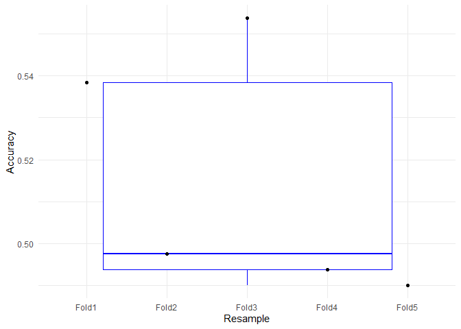

```r
#visualize accuracy scores
ggplot(data=eachfold_DT_uni_5, aes(x=Resample, y=Accuracy, group=1)) +
geom_boxplot(color="blue") +
geom_point() +
theme_minimal()
```

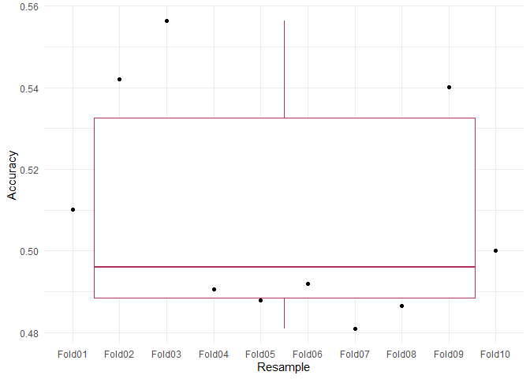

```r
#visualize accuracy scores
ggplot(data=eachfold_DT_uni, aes(x=Resample, y=Accuracy, group=1)) +
geom_boxplot(color="maroon") +
geom_point() +
theme_minimal()
```

From the decision tree, the TF-IDF model resulted in the highest accuracy at 59.35%; however, this is very close to the other models (Bag-of-Words, Unigrams). For all three algorithm-model combination, the word “thank” is the root node followed by “hour” and “great”.

### Random Forest

Apply the Random Forest algorithm to the three models: TF-IDF, Bag-of-Words, and Unigram.

#### TF-IDF

```r
RF_model_tfidf <- randomForest(class~., data = train_tfidf)

predictRF_tfidf <- predict(RF_model_tfidf, newdata = test_tfidf)

cf_RF_tfidf_loo <- confusionMatrix(table(test_tfidf$class, predictRF_tfidf)) #evaluation of confusion matrix

cf_RF_tfidf_loo
```

```
## Confusion Matrix and Statistics
##
##           predictRF_tfidf
##            negative neutral positive
##   negative      556     138       56
##   neutral       179     475       96
##   positive       94     128      487
##
## Overall Statistics
##
##                Accuracy : 0.6872
##                  95% CI : (0.6674, 0.7065)
##     No Information Rate : 0.3753
##     P-Value [Acc > NIR] : < 2.2e-16
##
##                   Kappa : 0.5302
##
##  Mcnemar's Test P-Value : 0.0002154
##
## Statistics by Class:
##
##                      Class: negative Class: neutral Class: positive
## Sensitivity                   0.6707         0.6410          0.7621
## Specificity                   0.8594         0.8127          0.8586
## Pos Pred Value                0.7413         0.6333          0.6869
## Neg Pred Value                0.8129         0.8177          0.8987
## Prevalence                    0.3753         0.3354          0.2893
## Detection Rate                0.2517         0.2150          0.2205
## Detection Prevalence          0.3395         0.3395          0.3210
## Balanced Accuracy             0.7651         0.7268          0.8104
```

Second attempt (5-fold, 10 trees)

```r
set.seed(12)
model_RF_tfidf_5 <- train(
  m_tfidf[,!names(m_tfidf) %in% c("class")], m_tfidf$class, "cforest", controls = cforest_unbiased(ntree = 10),
  trControl = trainControl(method = "cv", number = 5, savePredictions = "final", classProbs = TRUE)
)

model_RF_tfidf_5
```

```
## Conditional Inference Random Forest
##
## 7363 samples
##  138 predictor
##    3 classes: 'negative', 'neutral', 'positive'
##
## No pre-processing
## Resampling: Cross-Validated (5 fold)
## Summary of sample sizes: 5890, 5891, 5891, 5890, 5890
## Resampling results across tuning parameters:
##
##   mtry  Accuracy   Kappa
##     2   0.6342521  0.4501126
##    70   0.6373775  0.4549384
##   138   0.6323526  0.4473554
##
## Accuracy was used to select the optimal model using the largest value.
## The final value used for the model was mtry = 70.
```

```r
#create a confusion matrix for the best fold
cf_RF_tfidf_5 <- confusionMatrix(model_RF_tfidf_5$pred[order(model_RF_tfidf_5$pred$rowIndex),2], m_tfidf$class)

cf_RF_tfidf_5
```

```
## Confusion Matrix and Statistics
##
##           Reference
## Prediction negative neutral positive
##   negative     1322     332      175
##   neutral      1023    1893      710
##   positive      155     275     1478
##
## Overall Statistics
##
##                Accuracy : 0.6374
##                  95% CI : (0.6263, 0.6484)
##     No Information Rate : 0.3395
##     P-Value [Acc > NIR] : < 2.2e-16
##
##                   Kappa : 0.4549
##
##  Mcnemar's Test P-Value : < 2.2e-16
##
## Statistics by Class:
##
##                      Class: negative Class: neutral Class: positive
## Sensitivity                   0.5288         0.7572          0.6255
## Specificity                   0.8957         0.6436          0.9140
## Pos Pred Value                0.7228         0.5221          0.7746
## Neg Pred Value                0.7871         0.8376          0.8378
## Prevalence                    0.3395         0.3395          0.3209
## Detection Rate                0.1795         0.2571          0.2007
## Detection Prevalence          0.2484         0.4925          0.2591
## Balanced Accuracy             0.7123         0.7004          0.7697
```

```r
pred_RF_tfidf_5 <- model_RF_tfidf_5$pred
pred_RF_tfidf_5$equal <- ifelse(pred_RF_tfidf_5$pred == pred_RF_tfidf_5$obs, 1, 0)

eachfold_RF_tfidf_5 <- pred_RF_tfidf_5 %>%
  group_by(Resample) %>%
  summarise_at(vars(equal),
               list(Accuracy = mean))

eachfold_RF_tfidf_5
```

```
## # A tibble: 5 x 2
##   Resample Accuracy
##   <chr>       <dbl>
## 1 Fold1       0.616
## 2 Fold2       0.636
## 3 Fold3       0.649
## 4 Fold4       0.629
## 5 Fold5       0.657
```

Second attempt (10-fold, 10 trees)

```r
set.seed(1)
model_RF_tfidf <- train(
  m_tfidf[,!names(m_tfidf) %in% c("class")], m_tfidf$class, "cforest", controls = cforest_unbiased(ntree = 10),
  trControl = trainControl(method = "cv", number = 10, savePredictions = "final", classProbs = TRUE)
)

model_RF_tfidf
```

```
## Conditional Inference Random Forest
##
## 7363 samples
##  138 predictor
##    3 classes: 'negative', 'neutral', 'positive'
##
## No pre-processing
## Resampling: Cross-Validated (10 fold)
## Summary of sample sizes: 6627, 6627, 6626, 6627, 6626, 6626, ...
## Resampling results across tuning parameters:
##
##   mtry  Accuracy   Kappa
##     2   0.6396813  0.4581391
##    70   0.6391384  0.4575530
##   138   0.6361454  0.4529864
##
## Accuracy was used to select the optimal model using the largest value.
## The final value used for the model was mtry = 2.
```

```r
#create a confusion matrix for the best fold
cf_RF_tfidf <- confusionMatrix(model_RF_tfidf$pred[order(model_RF_tfidf$pred$rowIndex),2], m_tfidf$class)

cf_RF_tfidf
```

```
## Confusion Matrix and Statistics
##
##           Reference
## Prediction negative neutral positive
##   negative     1628     506      355
##   neutral       714    1725      651
##   positive      158     269     1357
##
## Overall Statistics
##
##                Accuracy : 0.6397
##                  95% CI : (0.6286, 0.6507)
##     No Information Rate : 0.3395
##     P-Value [Acc > NIR] : < 2.2e-16
##
##                   Kappa : 0.4582
##
##  Mcnemar's Test P-Value : < 2.2e-16
##
## Statistics by Class:
##
##                      Class: negative Class: neutral Class: positive
## Sensitivity                   0.6512         0.6900          0.5743
## Specificity                   0.8229         0.7193          0.9146
## Pos Pred Value                0.6541         0.5583          0.7607
## Neg Pred Value                0.8211         0.8186          0.8197
## Prevalence                    0.3395         0.3395          0.3209
## Detection Rate                0.2211         0.2343          0.1843
## Detection Prevalence          0.3380         0.4197          0.2423
## Balanced Accuracy             0.7371         0.7047          0.7444
```

```r
pred_RF_tfidf <- model_RF_tfidf$pred
pred_RF_tfidf$equal <- ifelse(pred_RF_tfidf$pred == pred_RF_tfidf$obs, 1, 0)

eachfold_RF_tfidf <- pred_RF_tfidf %>%
  group_by(Resample) %>%
  summarise_at(vars(equal),
               list(Accuracy = mean))

eachfold_RF_tfidf
```

```
## # A tibble: 10 x 2
##    Resample Accuracy
##    <chr>       <dbl>
##  1 Fold01      0.626
##  2 Fold02      0.654
##  3 Fold03      0.658
##  4 Fold04      0.626
##  5 Fold05      0.645
##  6 Fold06      0.643
##  7 Fold07      0.649
##  8 Fold08      0.649
##  9 Fold09      0.606
## 10 Fold10      0.640
```

Third attempt (10 fold, 50 trees)

```r
set.seed(11)
model_RF_tfidf_50 <- train(
  m_tfidf[,!names(m_tfidf) %in% c("class")], m_tfidf$class, "cforest", controls = cforest_unbiased(ntree = 50),
  trControl = trainControl(method = "cv", number = 10, savePredictions = "final", classProbs = TRUE)
)

#create a confusion matrix for the best fold
cf_RF_tfidf_50 <- confusionMatrix(model_RF_tfidf_50$pred[order(model_RF_tfidf_50$pred$rowIndex),2], m_tfidf$class)

cf_RF_tfidf_50
```

```
## Confusion Matrix and Statistics
##
##           Reference
## Prediction negative neutral positive
##   negative     1697     510      315
##   neutral       640    1715      570
##   positive      163     275     1478
##
## Overall Statistics
##
##                Accuracy : 0.6641
##                  95% CI : (0.6532, 0.6749)
##     No Information Rate : 0.3395
##     P-Value [Acc > NIR] : < 2.2e-16
##
##                   Kappa : 0.4952
##
##  Mcnemar's Test P-Value : < 2.2e-16
##
## Statistics by Class:
##
##                      Class: negative Class: neutral Class: positive
## Sensitivity                   0.6788         0.6860          0.6255
## Specificity                   0.8304         0.7512          0.9124
## Pos Pred Value                0.6729         0.5863          0.7714
## Neg Pred Value                0.8341         0.8231          0.8375
## Prevalence                    0.3395         0.3395          0.3209
## Detection Rate                0.2305         0.2329          0.2007
## Detection Prevalence          0.3425         0.3973          0.2602
## Balanced Accuracy             0.7546         0.7186          0.7689
```

```r
model_RF_tfidf_50
```

```
## Conditional Inference Random Forest
##
## 7363 samples
##  138 predictor
##    3 classes: 'negative', 'neutral', 'positive'
##
## No pre-processing
## Resampling: Cross-Validated (10 fold)
## Summary of sample sizes: 6627, 6626, 6626, 6627, 6627, 6626, ...
## Resampling results across tuning parameters:
##
##   mtry  Accuracy   Kappa
##     2   0.6641291  0.4951565
##    70   0.6429451  0.4633041
##   138   0.6346598  0.4507927
##
## Accuracy was used to select the optimal model using the largest value.
## The final value used for the model was mtry = 2.
```

```r
pred_RF_tfidf_50 <- model_RF_tfidf_50$pred
pred_RF_tfidf_50$equal <- ifelse(pred_RF_tfidf_50$pred == pred_RF_tfidf_50$obs, 1, 0)

eachfold_RF_tfidf_50 <- pred_RF_tfidf_50 %>%
  group_by(Resample) %>%
  summarise_at(vars(equal),
               list(Accuracy = mean))

eachfold_RF_tfidf_50
```

```
## # A tibble: 10 x 2
##    Resample Accuracy
##    <chr>       <dbl>
##  1 Fold01      0.643
##  2 Fold02      0.646
##  3 Fold03      0.664
##  4 Fold04      0.644
##  5 Fold05      0.671
##  6 Fold06      0.700
##  7 Fold07      0.639
##  8 Fold08      0.697
##  9 Fold09      0.664
## 10 Fold10      0.674
```

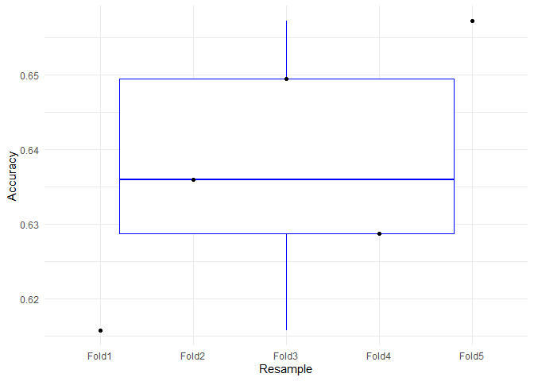

```r
#visualize accuracy scores
ggplot(data=eachfold_RF_tfidf_5, aes(x=Resample, y=Accuracy, group=1)) +
geom_boxplot(color="blue") +
geom_point() +
theme_minimal()
```

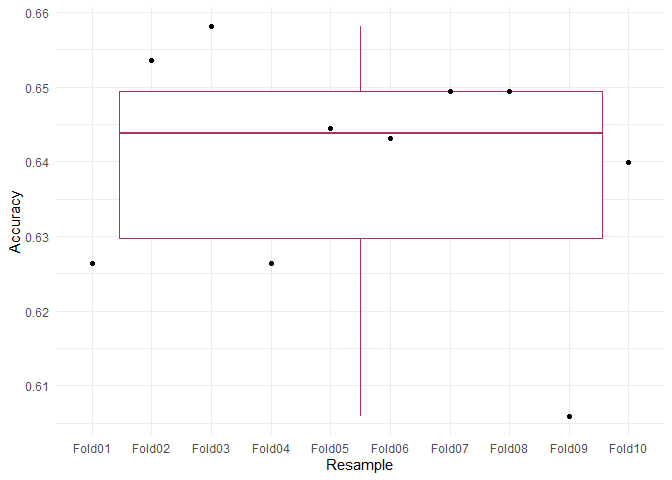

```r
#visualize accuracy scores
ggplot(data=eachfold_RF_tfidf, aes(x=Resample, y=Accuracy, group=1)) +
geom_boxplot(color="maroon") +
geom_point() +
theme_minimal()
```

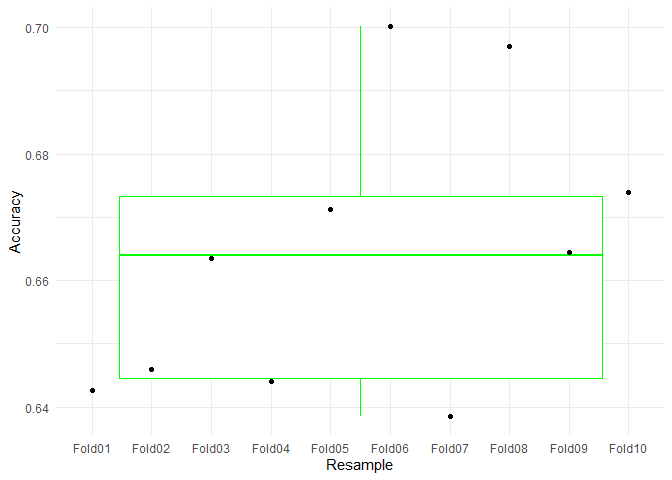

```r
#visualize accuracy scores
ggplot(data=eachfold_RF_tfidf_50, aes(x=Resample, y=Accuracy, group=1)) +
  geom_boxplot(color="green") +
  geom_point() +
  theme_minimal()
```

#### Bag-of-Words

```r
RF_model_bow <- randomForest(class~., data = train_bow)

predictRF_bow <- predict(RF_model_bow, newdata = test_bow)

cf_RF_bow_loo <- confusionMatrix(table(test_bow$class, predictRF_bow)) #evaluation of confusion matrix

cf_RF_bow_loo
```

```
## Confusion Matrix and Statistics
##
##           predictRF_bow
##            negative neutral positive
##   negative      537     158       55
##   neutral       163     484      103
##   positive       83     152      474
##
## Overall Statistics
##
##                Accuracy : 0.6768
##                  95% CI : (0.6568, 0.6963)
##     No Information Rate : 0.3594
##     P-Value [Acc > NIR] : < 2.2e-16
##
##                   Kappa : 0.5145
##
##  Mcnemar's Test P-Value : 0.001673
##
## Statistics by Class:
##
##                      Class: negative Class: neutral Class: positive
## Sensitivity                   0.6858         0.6096          0.7500
## Specificity                   0.8506         0.8120          0.8510
## Pos Pred Value                0.7160         0.6453          0.6685
## Neg Pred Value                0.8314         0.7875          0.8947
## Prevalence                    0.3545         0.3594          0.2861
## Detection Rate                0.2431         0.2191          0.2146
## Detection Prevalence          0.3395         0.3395          0.3210
## Balanced Accuracy             0.7682         0.7108          0.8005
```

Second attempt (5-fold, 10 trees)

```r
set.seed(22)
model_RF_bow_5 <- train(
  m_bow[,!names(m_bow) %in% c("class")], m_bow$class, "cforest", controls = cforest_unbiased(ntree = 10),
  trControl = trainControl(method = "cv", number = 5, savePredictions = "final", classProbs = TRUE)
)

model_RF_bow_5
```

```
## Conditional Inference Random Forest
##
## 7363 samples
##  138 predictor
##    3 classes: 'negative', 'neutral', 'positive'
##
## No pre-processing
## Resampling: Cross-Validated (5 fold)
## Summary of sample sizes: 5890, 5890, 5891, 5891, 5890
## Resampling results across tuning parameters:
##
##   mtry  Accuracy   Kappa
##     2   0.6390032  0.4571527
##    70   0.6388697  0.4571448
##   138   0.6361534  0.4530176
##
## Accuracy was used to select the optimal model using the largest value.
## The final value used for the model was mtry = 2.
```

```r
#create a confusion matrix for the best fold
cf_RF_bow_5 <- confusionMatrix(model_RF_bow_5$pred[order(model_RF_bow_5$pred$rowIndex),2], m_bow$class)

cf_RF_bow_5
```

```
## Confusion Matrix and Statistics
##
##           Reference
## Prediction negative neutral positive
##   negative     1554     474      326
##   neutral       772    1776      662
##   positive      174     250     1375
##
## Overall Statistics
##
##                Accuracy : 0.639
##                  95% CI : (0.6279, 0.65)
##     No Information Rate : 0.3395
##     P-Value [Acc > NIR] : < 2.2e-16
##
##                   Kappa : 0.4572
##
##  Mcnemar's Test P-Value : < 2.2e-16
##
## Statistics by Class:
##
##                      Class: negative Class: neutral Class: positive
## Sensitivity                   0.6216         0.7104          0.5819
## Specificity                   0.8355         0.7051          0.9152
## Pos Pred Value                0.6602         0.5533          0.7643
## Neg Pred Value                0.8111         0.8257          0.8224
## Prevalence                    0.3395         0.3395          0.3209
## Detection Rate                0.2111         0.2412          0.1867
## Detection Prevalence          0.3197         0.4360          0.2443
## Balanced Accuracy             0.7285         0.7078          0.7485
```

```r
pred_RF_bow_5 <- model_RF_bow_5$pred
pred_RF_bow_5$equal <- ifelse(pred_RF_bow_5$pred == pred_RF_bow_5$obs, 1, 0)

eachfold_RF_bow_5 <- pred_RF_bow_5 %>%
  group_by(Resample) %>%
  summarise_at(vars(equal),
               list(Accuracy = mean))

eachfold_RF_bow_5
```

```
## # A tibble: 5 x 2
##   Resample Accuracy
##   <chr>       <dbl>
## 1 Fold1       0.659
## 2 Fold2       0.644
## 3 Fold3       0.636
## 4 Fold4       0.623
## 5 Fold5       0.633
```

Second attempt (10-fold, 10 trees)

```r
set.seed(2)
model_RF_bow <- train(
  m_bow[,!names(m_bow) %in% c("class")], m_bow$class, "cforest", controls = cforest_unbiased(ntree = 10),
  trControl = trainControl(method = "cv", number = 10, savePredictions = "final", classProbs = TRUE)
)

model_RF_bow
```

```
## Conditional Inference Random Forest
##
## 7363 samples
##  138 predictor
##    3 classes: 'negative', 'neutral', 'positive'
##
## No pre-processing
## Resampling: Cross-Validated (10 fold)
## Summary of sample sizes: 6627, 6627, 6626, 6627, 6626, 6626, ...
## Resampling results across tuning parameters:
##
##   mtry  Accuracy   Kappa
##     2   0.6369683  0.4540063
##    70   0.6396864  0.4583366
##   138   0.6349334  0.4511951
##
## Accuracy was used to select the optimal model using the largest value.
## The final value used for the model was mtry = 70.
```

```r
#create a confusion matrix for the best fold
cf_RF_bow <- confusionMatrix(model_RF_bow$pred[order(model_RF_bow$pred$rowIndex),2], m_bow$class)

cf_RF_bow
```

```
## Confusion Matrix and Statistics
##
##           Reference
## Prediction negative neutral positive
##   negative     1506     500      229
##   neutral       855    1734      664
##   positive      139     266     1470
##
## Overall Statistics
##
##                Accuracy : 0.6397
##                  95% CI : (0.6286, 0.6507)
##     No Information Rate : 0.3395
##     P-Value [Acc > NIR] : < 2.2e-16
##
##                   Kappa : 0.4583
##
##  Mcnemar's Test P-Value : < 2.2e-16
##
## Statistics by Class:
##
##                      Class: negative Class: neutral Class: positive
## Sensitivity                   0.6024         0.6936          0.6221
## Specificity                   0.8501         0.6876          0.9190
## Pos Pred Value                0.6738         0.5330          0.7840
## Neg Pred Value                0.8062         0.8136          0.8373
## Prevalence                    0.3395         0.3395          0.3209
## Detection Rate                0.2045         0.2355          0.1996
## Detection Prevalence          0.3035         0.4418          0.2547
## Balanced Accuracy             0.7262         0.6906          0.7705
```

```r
pred_RF_bow <- model_RF_bow$pred
pred_RF_bow$equal <- ifelse(pred_RF_bow$pred == pred_RF_bow$obs, 1, 0)

eachfold_RF_bow <- pred_RF_bow %>%
  group_by(Resample) %>%
  summarise_at(vars(equal),
               list(Accuracy = mean))

eachfold_RF_bow
```

```
## # A tibble: 10 x 2
##    Resample Accuracy
##    <chr>       <dbl>
##  1 Fold01      0.613
##  2 Fold02      0.644
##  3 Fold03      0.624
##  4 Fold04      0.662
##  5 Fold05      0.639
##  6 Fold06      0.645
##  7 Fold07      0.637
##  8 Fold08      0.674
##  9 Fold09      0.660
## 10 Fold10      0.599
```

Third attempt (10-fold, 50 trees)

```r
set.seed(21)
model_RF_bow_50 <- train(
  m_bow[,!names(m_bow) %in% c("class")], m_bow$class, "cforest", controls = cforest_unbiased(ntree = 50),
  trControl = trainControl(method = "cv", number = 10, savePredictions = "final", classProbs = TRUE)
)

model_RF_bow_50
```

```
## Conditional Inference Random Forest
##
## 7363 samples
##  138 predictor
##    3 classes: 'negative', 'neutral', 'positive'
##
## No pre-processing
## Resampling: Cross-Validated (10 fold)
## Summary of sample sizes: 6626, 6627, 6627, 6627, 6626, 6626, ...
## Resampling results across tuning parameters:
##
##   mtry  Accuracy   Kappa
##     2   0.6665748  0.4987940
##    70   0.6409117  0.4601701
##   138   0.6347996  0.4509189
##
## Accuracy was used to select the optimal model using the largest value.
## The final value used for the model was mtry = 2.
```

```r
#create a confusion matrix for the best fold
cf_RF_bow_50 <- confusionMatrix(model_RF_bow_50$pred[order(model_RF_bow_50$pred$rowIndex),2], m_bow$class)

cf_RF_bow_50
```

```
## Confusion Matrix and Statistics
##
##           Reference
## Prediction negative neutral positive
##   negative     1691     498      321
##   neutral       656    1739      564
##   positive      153     263     1478
##
## Overall Statistics
##
##                Accuracy : 0.6666
##                  95% CI : (0.6557, 0.6773)
##     No Information Rate : 0.3395
##     P-Value [Acc > NIR] : < 2.2e-16
##
##                   Kappa : 0.4988
##
##  Mcnemar's Test P-Value : < 2.2e-16
##
## Statistics by Class:
##
##                      Class: negative Class: neutral Class: positive
## Sensitivity                   0.6764         0.6956          0.6255
## Specificity                   0.8316         0.7491          0.9168
## Pos Pred Value                0.6737         0.5877          0.7804
## Neg Pred Value                0.8333         0.8272          0.8382
## Prevalence                    0.3395         0.3395          0.3209
## Detection Rate                0.2297         0.2362          0.2007
## Detection Prevalence          0.3409         0.4019          0.2572
## Balanced Accuracy             0.7540         0.7224          0.7711
```

```r
pred_RF_bow_50 <- model_RF_bow_50$pred
pred_RF_bow_50$equal <- ifelse(pred_RF_bow_50$pred == pred_RF_bow_50$obs, 1, 0)

eachfold_RF_bow_50 <- pred_RF_bow_50 %>%
  group_by(Resample) %>%
  summarise_at(vars(equal),
               list(Accuracy = mean))

eachfold_RF_bow_50
```

```
## # A tibble: 10 x 2
##    Resample Accuracy
##    <chr>       <dbl>
##  1 Fold01      0.699
##  2 Fold02      0.673
##  3 Fold03      0.658
##  4 Fold04      0.652
##  5 Fold05      0.666
##  6 Fold06      0.645
##  7 Fold07      0.668
##  8 Fold08      0.667
##  9 Fold09      0.677
## 10 Fold10      0.662
```

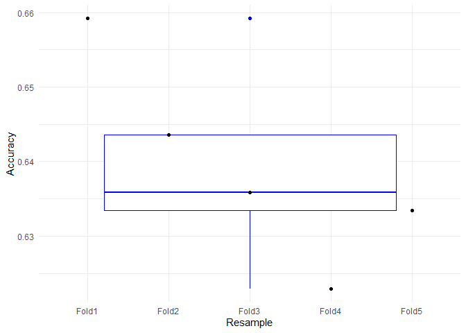

```r
#visualize accuracy scores
ggplot(data=eachfold_RF_bow_5, aes(x=Resample, y=Accuracy, group=1)) +
geom_boxplot(color="blue") +
geom_point() +
theme_minimal()
```

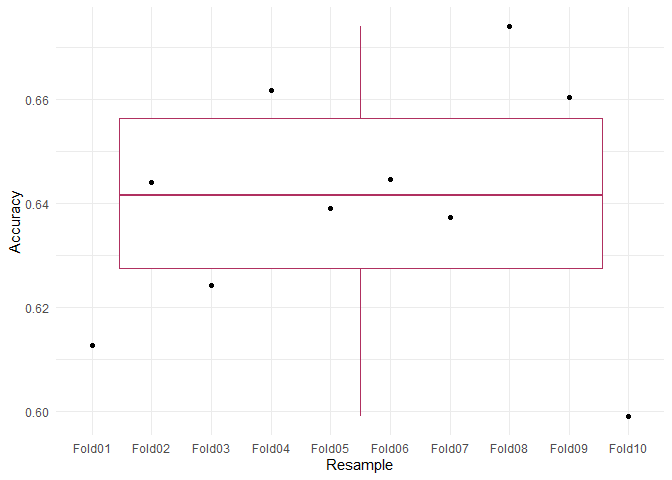

```r
#visualize accuracy scores
ggplot(data=eachfold_RF_bow, aes(x=Resample, y=Accuracy, group=1)) +
geom_boxplot(color="maroon") +
geom_point() +
theme_minimal()
```

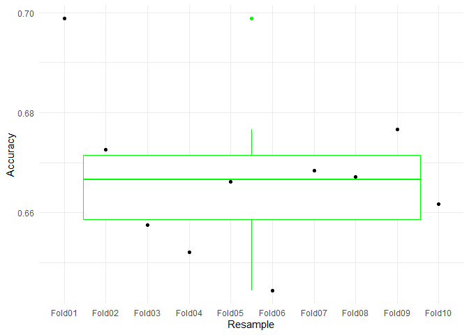

```r
#visualize accuracy scores
ggplot(data=eachfold_RF_bow_50, aes(x=Resample, y=Accuracy, group=1)) +
  geom_boxplot(color="green") +
  geom_point() +
  theme_minimal()
```

#### Unigram

```r
RF_model_uni <- randomForest(class~., data = train_uni)

predictRF_uni <- predict(RF_model_uni, newdata = test_uni)

cf_RF_uni_loo <- confusionMatrix(table(test_uni$class, predictRF_uni)) #evaluation of confusion matrix

cf_RF_uni_loo
```

```
## Confusion Matrix and Statistics
##
##           predictRF_uni
##            negative neutral positive
##   negative      517     177       56
##   neutral       157     494       99
##   positive      100     141      468
##
## Overall Statistics
##
##                Accuracy : 0.6695
##                  95% CI : (0.6495, 0.6891)
##     No Information Rate : 0.3676
##     P-Value [Acc > NIR] : < 2.2e-16
##
##                   Kappa : 0.5036
##
##  Mcnemar's Test P-Value : 0.0001074
##
## Statistics by Class:
##
##                      Class: negative Class: neutral Class: positive
## Sensitivity                   0.6680         0.6084          0.7512
## Specificity                   0.8376         0.8168          0.8480
## Pos Pred Value                0.6893         0.6587          0.6601
## Neg Pred Value                0.8239         0.7820          0.8967
## Prevalence                    0.3504         0.3676          0.2820
## Detection Rate                0.2340         0.2236          0.2119
## Detection Prevalence          0.3395         0.3395          0.3210
## Balanced Accuracy             0.7528         0.7126          0.7996
```

Second attempt (5-fold, 10 trees)

```r
set.seed(32)
model_RF_uni_5 <- train(
  m_uni[,!names(m_uni) %in% c("class")], m_uni$class, "cforest", controls = cforest_unbiased(ntree = 10),
  trControl = trainControl(method = "cv", number = 5, savePredictions = "final", classProbs = TRUE)
)

model_RF_uni_5
```

```
## Conditional Inference Random Forest
##
## 7363 samples
##  138 predictor
##    3 classes: 'negative', 'neutral', 'positive'
##
## No pre-processing
## Resampling: Cross-Validated (5 fold)
## Summary of sample sizes: 5890, 5891, 5891, 5890, 5890
## Resampling results across tuning parameters:
##
##   mtry  Accuracy   Kappa
##     2   0.6472911  0.4697478
##    70   0.6342525  0.4501382
##   138   0.6326235  0.4477264
##
## Accuracy was used to select the optimal model using the largest value.
## The final value used for the model was mtry = 2.
```

```r
#create a confusion matrix for the best fold
cf_RF_uni_5 <- confusionMatrix(model_RF_uni_5$pred[order(model_RF_uni_5$pred$rowIndex),2], m_uni$class)

cf_RF_uni_5
```

```
## Confusion Matrix and Statistics
##
##           Reference
## Prediction negative neutral positive
##   negative     1615     497      321
##   neutral       722    1728      619
##   positive      163     275     1423
##
## Overall Statistics
##
##                Accuracy : 0.6473
##                  95% CI : (0.6363, 0.6582)
##     No Information Rate : 0.3395
##     P-Value [Acc > NIR] : < 2.2e-16
##
##                   Kappa : 0.4697
##
##  Mcnemar's Test P-Value : < 2.2e-16
##
## Statistics by Class:
##
##                      Class: negative Class: neutral Class: positive
## Sensitivity                   0.6460         0.6912          0.6022
## Specificity                   0.8318         0.7242          0.9124
## Pos Pred Value                0.6638         0.5630          0.7646
## Neg Pred Value                0.8205         0.8202          0.8292
## Prevalence                    0.3395         0.3395          0.3209
## Detection Rate                0.2193         0.2347          0.1933
## Detection Prevalence          0.3304         0.4168          0.2528
## Balanced Accuracy             0.7389         0.7077          0.7573
```

```r
pred_RF_uni_5 <- model_RF_uni_5$pred
pred_RF_uni_5$equal <- ifelse(pred_RF_uni_5$pred == pred_RF_uni_5$obs, 1, 0)

eachfold_RF_uni_5 <- pred_RF_uni_5 %>%
  group_by(Resample) %>%
  summarise_at(vars(equal),
               list(Accuracy = mean))

eachfold_RF_uni_5
```

```
## # A tibble: 5 x 2
##   Resample Accuracy
##   <chr>       <dbl>
## 1 Fold1       0.652
## 2 Fold2       0.662
## 3 Fold3       0.637
## 4 Fold4       0.621
## 5 Fold5       0.665
```

Second attempt (10-fold, 10 trees)

```r
set.seed(3)
model_RF_uni <- train(
  m_uni[,!names(m_uni) %in% c("class")], m_uni$class, "cforest", controls = cforest_unbiased(ntree = 10),
  trControl = trainControl(method = "cv", number = 10, savePredictions = "final", classProbs = TRUE)
)

model_RF_uni
```

```
## Conditional Inference Random Forest
##
## 7363 samples
##  138 predictor
##    3 classes: 'negative', 'neutral', 'positive'
##
## No pre-processing
## Resampling: Cross-Validated (10 fold)
## Summary of sample sizes: 6627, 6627, 6626, 6627, 6626, 6627, ...
## Resampling results across tuning parameters:
##
##   mtry  Accuracy   Kappa
##     2   0.6468857  0.4690465
##    70   0.6430815  0.4634418
##   138   0.6308603  0.4449494
##
## Accuracy was used to select the optimal model using the largest value.
## The final value used for the model was mtry = 2.
```

```r
#create a confusion matrix for the best fold
cf_RF_uni <- confusionMatrix(model_RF_uni$pred[order(model_RF_uni$pred$rowIndex),2], m_uni$class)

cf_RF_uni
```

```
## Confusion Matrix and Statistics
##
##           Reference
## Prediction negative neutral positive
##   negative     1605     485      343
##   neutral       723    1764      626
##   positive      172     251     1394
##
## Overall Statistics
##
##                Accuracy : 0.6469
##                  95% CI : (0.6358, 0.6578)
##     No Information Rate : 0.3395
##     P-Value [Acc > NIR] : < 2.2e-16
##
##                   Kappa : 0.469
##
##  Mcnemar's Test P-Value : < 2.2e-16
##
## Statistics by Class:
##
##                      Class: negative Class: neutral Class: positive
## Sensitivity                   0.6420         0.7056          0.5899
## Specificity                   0.8297         0.7226          0.9154
## Pos Pred Value                0.6597         0.5667          0.7672
## Neg Pred Value                0.8185         0.8268          0.8253
## Prevalence                    0.3395         0.3395          0.3209
## Detection Rate                0.2180         0.2396          0.1893
## Detection Prevalence          0.3304         0.4228          0.2468
## Balanced Accuracy             0.7359         0.7141          0.7527
```

```r
pred_RF_uni <- model_RF_uni$pred
pred_RF_uni$equal <- ifelse(pred_RF_uni$pred == pred_RF_uni$obs, 1, 0)

eachfold_RF_uni <- pred_RF_uni %>%
  group_by(Resample) %>%
  summarise_at(vars(equal),
               list(Accuracy = mean))

eachfold_RF_uni
```

```
## # A tibble: 10 x 2
##    Resample Accuracy
##    <chr>       <dbl>
##  1 Fold01      0.654
##  2 Fold02      0.667
##  3 Fold03      0.643
##  4 Fold04      0.639
##  5 Fold05      0.645
##  6 Fold06      0.635
##  7 Fold07      0.648
##  8 Fold08      0.671
##  9 Fold09      0.635
## 10 Fold10      0.634
```

Third attempt (10 fold, 50 trees)

```r
set.seed(31)
model_RF_uni_50 <- train(
  m_uni[,!names(m_uni) %in% c("class")], m_uni$class, "cforest", controls = cforest_unbiased(ntree = 50),
  trControl = trainControl(method = "cv", number = 10, savePredictions = "final", classProbs = TRUE)
)

model_RF_uni_50
```

```
## Conditional Inference Random Forest
##
## 7363 samples
##  138 predictor
##    3 classes: 'negative', 'neutral', 'positive'
##
## No pre-processing
## Resampling: Cross-Validated (10 fold)
## Summary of sample sizes: 6626, 6627, 6627, 6627, 6627, 6627, ...
## Resampling results across tuning parameters:
##
##   mtry  Accuracy   Kappa
##     2   0.6694258  0.5030358
##    70   0.6366988  0.4538232
##   138   0.6333035  0.4487029
##
## Accuracy was used to select the optimal model using the largest value.
## The final value used for the model was mtry = 2.
```

```r
#create a confusion matrix for the best fold
cf_RF_uni_50 <- confusionMatrix(model_RF_uni_50$pred[order(model_RF_uni_50$pred$rowIndex),2],m_uni$class)

cf_RF_uni_50
```

```
## Confusion Matrix and Statistics
##
##           Reference
## Prediction negative neutral positive
##   negative     1707     492      316
##   neutral       656    1748      573
##   positive      137     260     1474
##
## Overall Statistics
##
##                Accuracy : 0.6694
##                  95% CI : (0.6585, 0.6802)
##     No Information Rate : 0.3395
##     P-Value [Acc > NIR] : < 2.2e-16
##
##                   Kappa : 0.503
##
##  Mcnemar's Test P-Value : < 2.2e-16
##
## Statistics by Class:
##
##                      Class: negative Class: neutral Class: positive
## Sensitivity                   0.6828         0.6992          0.6238
## Specificity                   0.8338         0.7473          0.9206
## Pos Pred Value                0.6787         0.5872          0.7878
## Neg Pred Value                0.8364         0.8285          0.8381
## Prevalence                    0.3395         0.3395          0.3209
## Detection Rate                0.2318         0.2374          0.2002
## Detection Prevalence          0.3416         0.4043          0.2541
## Balanced Accuracy             0.7583         0.7232          0.7722
```

```r
pred_RF_uni_50 <- model_RF_uni_50$pred
pred_RF_uni_50$equal <- ifelse(pred_RF_uni_50$pred == pred_RF_uni_50$obs, 1, 0)

eachfold_RF_uni_50 <- pred_RF_uni_50 %>%
  group_by(Resample) %>%
  summarise_at(vars(equal),
               list(Accuracy = mean))

eachfold_RF_uni_50
```

```
## # A tibble: 10 x 2
##    Resample Accuracy
##    <chr>       <dbl>
##  1 Fold01      0.669
##  2 Fold02      0.652
##  3 Fold03      0.668
##  4 Fold04      0.652
##  5 Fold05      0.655
##  6 Fold06      0.671
##  7 Fold07      0.694
##  8 Fold08      0.675
##  9 Fold09      0.685
## 10 Fold10      0.672
```

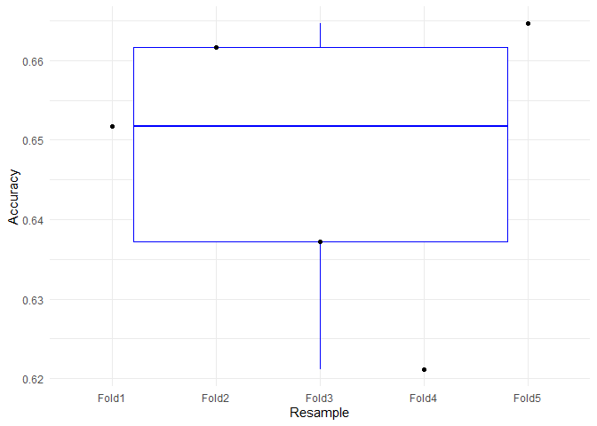

```r
#visualize accuracy scores
ggplot(data=eachfold_RF_uni_5, aes(x=Resample, y=Accuracy, group=1)) +
geom_boxplot(color="blue") +
geom_point() +
theme_minimal()
```

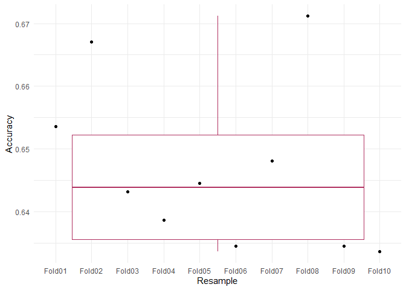

```r
#visualize accuracy scores
ggplot(data=eachfold_RF_uni, aes(x=Resample, y=Accuracy, group=1)) +
geom_boxplot(color="maroon") +
geom_point() +
theme_minimal()
```

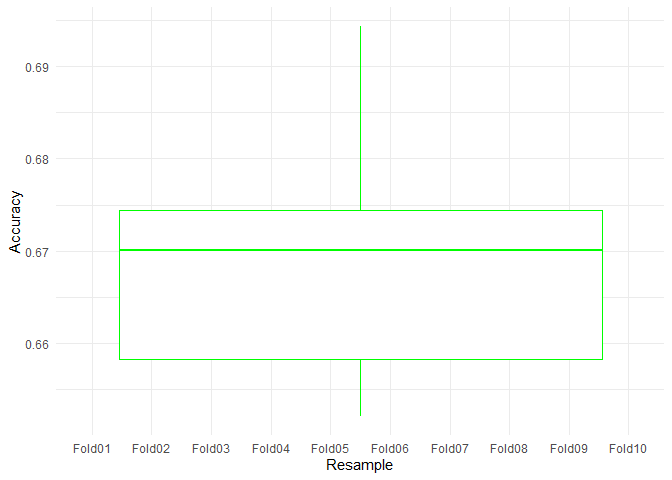

```r
#visualize accuracy scores
ggplot(data=eachfold_RF_uni_50, aes(x=Resample, y=Accuracy, group=1)) +
  geom_boxplot(color="green") +
  theme_minimal()
```

### Naive Bayes

Apply the Naive Bayes algorithm to the three models: TF-IDF, Bag-of-Words, and Unigram.

#### TF-IDF

```r
NB_model_tfidf <- naiveBayes(class~., data = train_tfidf)

predictNB_tfidf <- predict(NB_model_tfidf, newdata = test_tfidf)

cf_NB_tfidf_loo <- confusionMatrix(table(test_tfidf$class, predictNB_tfidf)) #evaluation of confusion matrix

cf_NB_tfidf_loo
```

```
## Confusion Matrix and Statistics
##
##           predictNB_tfidf
##            negative neutral positive
##   negative      503     117      130
##   neutral       305     270      175
##   positive      157     116      436
##
## Overall Statistics
##
##                Accuracy : 0.5473
##                  95% CI : (0.5263, 0.5682)
##     No Information Rate : 0.4368
##     P-Value [Acc > NIR] : < 2.2e-16
##
##                   Kappa : 0.321
##
##  Mcnemar's Test P-Value : < 2.2e-16
##
## Statistics by Class:
##
##                      Class: negative Class: neutral Class: positive
## Sensitivity                   0.5212         0.5368          0.5884
## Specificity                   0.8014         0.7186          0.8140
## Pos Pred Value                0.6707         0.3600          0.6150
## Neg Pred Value                0.6833         0.8403          0.7967
## Prevalence                    0.4368         0.2277          0.3354
## Detection Rate                0.2277         0.1222          0.1974
## Detection Prevalence          0.3395         0.3395          0.3210
## Balanced Accuracy             0.6613         0.6277          0.7012
```

Second attempt (5-fold)

```r
set.seed(92138)
model_NB_tfidf_5 <- train(
  m_tfidf[,!names(m_tfidf) %in% c("class")], m_tfidf$class, "nb",
  trControl = trainControl(method = "cv", number = 5, savePredictions = "final", classProbs = TRUE)
)

model_NB_tfidf_5
```

```
## Naive Bayes
##
## 7363 samples
##  138 predictor
##    3 classes: 'negative', 'neutral', 'positive'
##
## No pre-processing
## Resampling: Cross-Validated (5 fold)
## Summary of sample sizes: 5891, 5891, 5890, 5890, 5890
## Resampling results across tuning parameters:
##
##   usekernel  Accuracy   Kappa
##   FALSE      0.5617272  0.3432141
##    TRUE      0.5162278  0.2753618
##
## Tuning parameter 'fL' was held constant at a value of 0
## Tuning
##  parameter 'adjust' was held constant at a value of 1
## Accuracy was used to select the optimal model using the largest value.
## The final values used for the model were fL = 0, usekernel = FALSE and adjust
##  = 1.
```

```r
#create a confusion matrix for the best fold
cf_NB_tfidf_5 <- confusionMatrix(model_NB_tfidf_5$pred[order(model_NB_tfidf_5$pred$rowIndex),4], m_tfidf$class)

cf_NB_tfidf_5
```

```
## Confusion Matrix and Statistics
##
##           Reference
## Prediction negative neutral positive
##   negative     1662     815      410
##   neutral       408     942      421
##   positive      430     743     1532
##
## Overall Statistics
##
##                Accuracy : 0.5617
##                  95% CI : (0.5503, 0.5731)
##     No Information Rate : 0.3395
##     P-Value [Acc > NIR] : < 2.2e-16
##
##                   Kappa : 0.3432
##
##  Mcnemar's Test P-Value : < 2.2e-16
##
## Statistics by Class:
##
##                      Class: negative Class: neutral Class: positive
## Sensitivity                   0.6648         0.3768          0.6483
## Specificity                   0.7481         0.8295          0.7654
## Pos Pred Value                0.5757         0.5319          0.5664
## Neg Pred Value                0.8128         0.7214          0.8216
## Prevalence                    0.3395         0.3395          0.3209
## Detection Rate                0.2257         0.1279          0.2081
## Detection Prevalence          0.3921         0.2405          0.3674
## Balanced Accuracy             0.7064         0.6032          0.7069
```

```r
#display individual fold accuracies
pred_NB_tfidf_5 <- model_NB_tfidf_5$pred
pred_NB_tfidf_5$equal <- ifelse(pred_NB_tfidf_5$pred == pred_NB_tfidf_5$obs, 1, 0)

eachfold_NB_tfidf_5 <- pred_NB_tfidf_5 %>%
  group_by(Resample) %>%
  summarise_at(vars(equal),
               list(Accuracy = mean))

eachfold_NB_tfidf_5
```

```
## # A tibble: 5 x 2
##   Resample Accuracy
##   <chr>       <dbl>
## 1 Fold1       0.558
## 2 Fold2       0.562
## 3 Fold3       0.563
## 4 Fold4       0.572
## 5 Fold5       0.552
```

Third attempt (10-fold)

```r
set.seed(92132)
set.seed(92132)
model_NB_tfidf <- train(
  m_tfidf[,!names(m_tfidf) %in% c("class")], m_tfidf$class, "nb",
  trControl = trainControl(method = "cv", number = 10, savePredictions = "final", classProbs = TRUE)
)

model_NB_tfidf
```

```
## Naive Bayes
##
## 7363 samples
##  138 predictor
##    3 classes: 'negative', 'neutral', 'positive'
##
## No pre-processing
## Resampling: Cross-Validated (10 fold)
## Summary of sample sizes: 6627, 6626, 6627, 6627, 6627, 6627, ...
## Resampling results across tuning parameters:
##
##   usekernel  Accuracy   Kappa
##   FALSE      0.5591468  0.3392112
##    TRUE      0.5097105  0.2652274
##
## Tuning parameter 'fL' was held constant at a value of 0
## Tuning
##  parameter 'adjust' was held constant at a value of 1
## Accuracy was used to select the optimal model using the largest value.
## The final values used for the model were fL = 0, usekernel = FALSE and adjust
##  = 1.
```

```r
#create a confusion matrix for the best fold
cf_NB_tfidf <- confusionMatrix(model_NB_tfidf$pred[order(model_NB_tfidf$pred$rowIndex),4], m_tfidf$class)

cf_NB_tfidf
```

```
## Confusion Matrix and Statistics
##
##           Reference
## Prediction negative neutral positive
##   negative     1671     831      455
##   neutral       396     946      408
##   positive      433     723     1500
##
## Overall Statistics
##
##                Accuracy : 0.5591
##                  95% CI : (0.5477, 0.5705)
##     No Information Rate : 0.3395
##     P-Value [Acc > NIR] : < 2.2e-16
##
##                   Kappa : 0.3392
##
##  Mcnemar's Test P-Value : < 2.2e-16
##
## Statistics by Class:
##
##                      Class: negative Class: neutral Class: positive
## Sensitivity                   0.6684         0.3784          0.6348
## Specificity                   0.7356         0.8347          0.7688
## Pos Pred Value                0.5651         0.5406          0.5648
## Neg Pred Value                0.8118         0.7231          0.8167
## Prevalence                    0.3395         0.3395          0.3209
## Detection Rate                0.2269         0.1285          0.2037
## Detection Prevalence          0.4016         0.2377          0.3607
## Balanced Accuracy             0.7020         0.6065          0.7018
```

```r
#display individual fold accuracies
pred_NB_tfidf <- model_NB_tfidf$pred
pred_NB_tfidf$equal <- ifelse(pred_NB_tfidf$pred == pred_NB_tfidf$obs, 1, 0)

eachfold_NB_tfidf <- pred_NB_tfidf %>%
  group_by(Resample) %>%
  summarise_at(vars(equal),
               list(Accuracy = mean))

eachfold_NB_tfidf
```

```
## # A tibble: 10 x 2
##    Resample Accuracy
##    <chr>       <dbl>
##  1 Fold01      0.534
##  2 Fold02      0.545
##  3 Fold03      0.577
##  4 Fold04      0.577
##  5 Fold05      0.548
##  6 Fold06      0.543
##  7 Fold07      0.549
##  8 Fold08      0.583
##  9 Fold09      0.562
## 10 Fold10      0.573
```

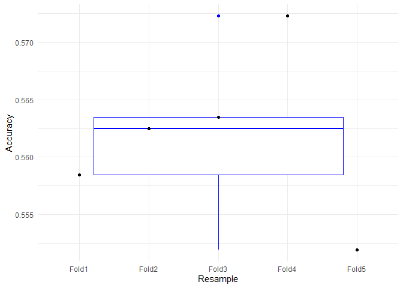

```r
#visualize accuracy scores
ggplot(data=eachfold_NB_tfidf_5, aes(x=Resample, y=Accuracy, group=1)) +
geom_boxplot(color="blue") +
geom_point() +
theme_minimal()
```

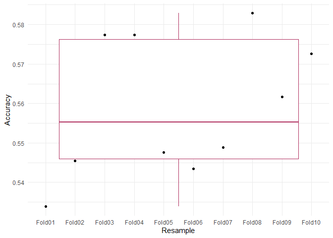

```r
#visualize accuracy scores
ggplot(data=eachfold_NB_tfidf, aes(x=Resample, y=Accuracy, group=1)) +
geom_boxplot(color="maroon") +
geom_point() +
theme_minimal()
```

#### Bag-of-Words

```r
NB_model_bow <- naiveBayes(class~., data = train_bow)

predictNB_bow <- predict(NB_model_bow, newdata = test_bow)

cf_NB_bow_loo <- confusionMatrix(table(test_bow$class, predictNB_bow)) #evaluation of confusion matrix

cf_NB_bow_loo
```

```
## Confusion Matrix and Statistics
##
##           predictNB_bow
##            negative neutral positive
##   negative      454     189      107
##   neutral       110     506      134
##   positive       80     236      393
##
## Overall Statistics
##
##                Accuracy : 0.6125
##                  95% CI : (0.5918, 0.6329)
##     No Information Rate : 0.4215
##     P-Value [Acc > NIR] : < 2.2e-16
##
##                   Kappa : 0.418
##
##  Mcnemar's Test P-Value : 1.935e-11
##
## Statistics by Class:
##
##                      Class: negative Class: neutral Class: positive
## Sensitivity                   0.7050         0.5435          0.6199
## Specificity                   0.8109         0.8091          0.7994
## Pos Pred Value                0.6053         0.6747          0.5543
## Neg Pred Value                0.8698         0.7087          0.8393
## Prevalence                    0.2915         0.4215          0.2870
## Detection Rate                0.2055         0.2291          0.1779
## Detection Prevalence          0.3395         0.3395          0.3210
## Balanced Accuracy             0.7579         0.6763          0.7096
```

Second attempt (5-fold validation)

```r
set.seed(45894)
model_NB_bow_5 <- train(
  m_bow[,!names(m_bow) %in% c("class")], m_bow$class, "nb", trControl = trainControl(method = "cv", number = 5, savePredictions = "final", classProbs = TRUE)
)

model_NB_bow_5
```

```
## Naive Bayes
##
## 7363 samples
##  138 predictor
##    3 classes: 'negative', 'neutral', 'positive'
##
## No pre-processing
## Resampling: Cross-Validated (5 fold)
## Summary of sample sizes: 5890, 5891, 5890, 5891, 5890
## Resampling results across tuning parameters:
##
##   usekernel  Accuracy   Kappa
##   FALSE      0.6197188  0.429083040
##    TRUE      0.3441539  0.007142015
##
## Tuning parameter 'fL' was held constant at a value of 0
## Tuning
##  parameter 'adjust' was held constant at a value of 1
## Accuracy was used to select the optimal model using the largest value.
## The final values used for the model were fL = 0, usekernel = FALSE and adjust
##  = 1.
```

```r
#create a confusion matrix for the best fold
cf_NB_bow_5 <- confusionMatrix(model_NB_bow_5$pred[order(model_NB_bow_5$pred$rowIndex),4], m_bow$class)

cf_NB_bow_5
```

```
## Confusion Matrix and Statistics
##
##           Reference
## Prediction negative neutral positive
##   negative     1490     392      254
##   neutral       595    1688      724
##   positive      415     420     1385
##
## Overall Statistics
##
##                Accuracy : 0.6197
##                  95% CI : (0.6085, 0.6308)
##     No Information Rate : 0.3395
##     P-Value [Acc > NIR] : < 2.2e-16
##
##                   Kappa : 0.4291
##
##  Mcnemar's Test P-Value : < 2.2e-16
##
## Statistics by Class:
##
##                      Class: negative Class: neutral Class: positive
## Sensitivity                   0.5960         0.6752          0.5861
## Specificity                   0.8672         0.7288          0.8330
## Pos Pred Value                0.6976         0.5614          0.6239
## Neg Pred Value                0.8068         0.8136          0.8098
## Prevalence                    0.3395         0.3395          0.3209
## Detection Rate                0.2024         0.2293          0.1881
## Detection Prevalence          0.2901         0.4084          0.3015
## Balanced Accuracy             0.7316         0.7020          0.7096
```

```r
#display individual fold accuracies
pred_NB_bow_5 <- model_NB_bow_5$pred
pred_NB_bow_5$equal <- ifelse(pred_NB_bow_5$pred == pred_NB_bow_5$obs, 1, 0)

eachfold_NB_bow_5 <- pred_NB_bow_5 %>%
  group_by(Resample) %>%
  summarise_at(vars(equal),
               list(Accuracy = mean))

eachfold_NB_bow_5
```

```
## # A tibble: 5 x 2
##   Resample Accuracy
##   <chr>       <dbl>
## 1 Fold1       0.643
## 2 Fold2       0.613
## 3 Fold3       0.627
## 4 Fold4       0.616
## 5 Fold5       0.599
```

Third attempt (10-fold validation)

```r
set.seed(45892)
model_NB_bow <- train(
  m_bow[,!names(m_bow) %in% c("class")], m_bow$class, "nb",
  trControl = trainControl(method = "cv", number = 10, savePredictions = "final", classProbs = TRUE)
)

model_NB_bow
```

```
## Naive Bayes
##
## 7363 samples
##  138 predictor
##    3 classes: 'negative', 'neutral', 'positive'
##
## No pre-processing
## Resampling: Cross-Validated (10 fold)
## Summary of sample sizes: 6627, 6626, 6627, 6627, 6627, 6627, ...
## Resampling results across tuning parameters:
##
##   usekernel  Accuracy   Kappa
##   FALSE      0.6183678  0.426953766
##    TRUE      0.3441539  0.007170399
##
## Tuning parameter 'fL' was held constant at a value of 0
## Tuning
##  parameter 'adjust' was held constant at a value of 1
## Accuracy was used to select the optimal model using the largest value.
## The final values used for the model were fL = 0, usekernel = FALSE and adjust
##  = 1.
```

```r
#create a confusion matrix for the best fold
cf_NB_bow <- confusionMatrix(model_NB_bow$pred[order(model_NB_bow$pred$rowIndex),4], m_bow$class)

cf_NB_bow
```

```
## Confusion Matrix and Statistics
##
##           Reference
## Prediction negative neutral positive
##   negative     1498     391      261
##   neutral       596    1695      742
##   positive      406     414     1360
##
## Overall Statistics
##
##                Accuracy : 0.6184
##                  95% CI : (0.6072, 0.6295)
##     No Information Rate : 0.3395
##     P-Value [Acc > NIR] : < 2.2e-16
##
##                   Kappa : 0.4269
##
##  Mcnemar's Test P-Value : < 2.2e-16
##
## Statistics by Class:
##
##                      Class: negative Class: neutral Class: positive
## Sensitivity                   0.5992         0.6780          0.5755
## Specificity                   0.8659         0.7249          0.8360
## Pos Pred Value                0.6967         0.5589          0.6239
## Neg Pred Value                0.8078         0.8141          0.8065
## Prevalence                    0.3395         0.3395          0.3209
## Detection Rate                0.2034         0.2302          0.1847
## Detection Prevalence          0.2920         0.4119          0.2961
## Balanced Accuracy             0.7326         0.7014          0.7058
```

```r
#display individual fold accuracies
pred_NB_bow <- model_NB_bow$pred
pred_NB_bow$equal <- ifelse(pred_NB_bow$pred == pred_NB_bow$obs, 1, 0)

eachfold_NB_bow <- pred_NB_bow %>%
  group_by(Resample) %>%
  summarise_at(vars(equal),
               list(Accuracy = mean))

eachfold_NB_bow
```

```
## # A tibble: 10 x 2
##    Resample Accuracy
##    <chr>       <dbl>
##  1 Fold01      0.620
##  2 Fold02      0.578
##  3 Fold03      0.610
##  4 Fold04      0.635
##  5 Fold05      0.635
##  6 Fold06      0.611
##  7 Fold07      0.636
##  8 Fold08      0.624
##  9 Fold09      0.611
## 10 Fold10      0.625
```

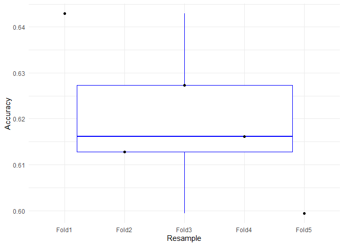

```r
#visualize accuracy scores
ggplot(data=eachfold_NB_bow_5, aes(x=Resample, y=Accuracy, group=1)) +
geom_boxplot(color="blue") +
geom_point() +
theme_minimal()
```

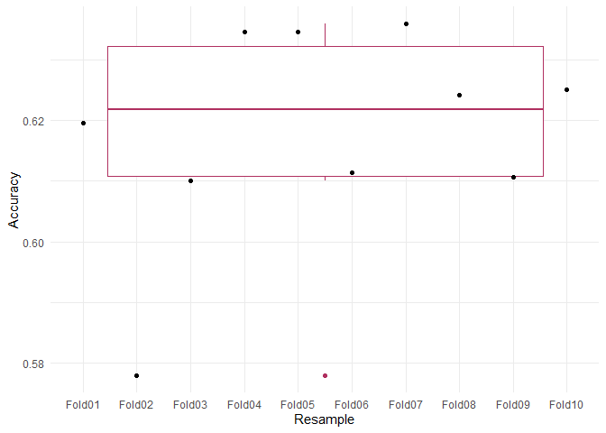

```r
#visualize accuracy scores
ggplot(data=eachfold_NB_bow, aes(x=Resample, y=Accuracy, group=1)) +
geom_boxplot(color="maroon") +
geom_point() +
theme_minimal()
```

#### Unigram

```r
NB_model_uni <- naiveBayes(class~., data = train_uni)

predictNB_uni <- predict(NB_model_uni, newdata = test_uni)

cf_NB_uni_loo <- confusionMatrix(table(test_uni$class, predictNB_uni)) #evaluation of confusion matrix

cf_NB_uni_loo
```

```
## Confusion Matrix and Statistics
##
##           predictNB_uni
##            negative neutral positive
##   negative      444     177      129
##   neutral       118     507      125
##   positive       77     233      399
##
## Overall Statistics
##
##                Accuracy : 0.6111
##                  95% CI : (0.5904, 0.6315)
##     No Information Rate : 0.4151
##     P-Value [Acc > NIR] : < 2.2e-16
##
##                   Kappa : 0.4161
##
##  Mcnemar's Test P-Value : 2.003e-12
##
## Statistics by Class:
##
##                      Class: negative Class: neutral Class: positive
## Sensitivity                   0.6948         0.5529          0.6110
## Specificity                   0.8051         0.8119          0.8008
## Pos Pred Value                0.5920         0.6760          0.5628
## Neg Pred Value                0.8663         0.7190          0.8307
## Prevalence                    0.2893         0.4151          0.2956
## Detection Rate                0.2010         0.2295          0.1806
## Detection Prevalence          0.3395         0.3395          0.3210
## Balanced Accuracy             0.7500         0.6824          0.7059
```

Second attempt (5-fold validation)

```r
set.seed(8920)
model_NB_uni_5 <- train(
  m_uni[,!names(m_uni) %in% c("class")], m_uni$class, "nb", trControl = trainControl(method = "cv", number = 5, savePredictions = "final", classProbs = TRUE)
)

model_NB_uni_5
```

```
## Naive Bayes
##
## 7363 samples
##  138 predictor
##    3 classes: 'negative', 'neutral', 'positive'
##
## No pre-processing
## Resampling: Cross-Validated (5 fold)
## Summary of sample sizes: 5890, 5890, 5891, 5891, 5890
## Resampling results across tuning parameters:
##
##   usekernel  Accuracy   Kappa
##   FALSE      0.6232516  0.43441300
##    TRUE      0.3465992  0.01092575
##
## Tuning parameter 'fL' was held constant at a value of 0
## Tuning
##  parameter 'adjust' was held constant at a value of 1
## Accuracy was used to select the optimal model using the largest value.
## The final values used for the model were fL = 0, usekernel = FALSE and adjust
##  = 1.
```

```r
#create a confusion matrix for the best fold
cf_NB_uni_5 <- confusionMatrix(model_NB_uni_5$pred[order(model_NB_uni_5$pred$rowIndex),4], m_uni$class)

cf_NB_uni_5
```

```
## Confusion Matrix and Statistics
##
##           Reference
## Prediction negative neutral positive
##   negative     1502     402      264
##   neutral       594    1672      684
##   positive      404     426     1415
##
## Overall Statistics
##
##                Accuracy : 0.6233
##                  95% CI : (0.6121, 0.6343)
##     No Information Rate : 0.3395
##     P-Value [Acc > NIR] : < 2.2e-16
##
##                   Kappa : 0.4344
##
##  Mcnemar's Test P-Value : < 2.2e-16
##
## Statistics by Class:
##
##                      Class: negative Class: neutral Class: positive
## Sensitivity                   0.6008         0.6688          0.5988
## Specificity                   0.8630         0.7372          0.8340
## Pos Pred Value                0.6928         0.5668          0.6303
## Neg Pred Value                0.8079         0.8124          0.8148
## Prevalence                    0.3395         0.3395          0.3209
## Detection Rate                0.2040         0.2271          0.1922
## Detection Prevalence          0.2944         0.4007          0.3049
## Balanced Accuracy             0.7319         0.7030          0.7164
```

```r
#display individual fold accuracies
pred_NB_uni_5 <- model_NB_uni_5$pred
pred_NB_uni_5$equal <- ifelse(pred_NB_uni_5$pred == pred_NB_uni_5$obs, 1, 0)

eachfold_NB_uni_5 <- pred_NB_uni_5 %>%
  group_by(Resample) %>%
  summarise_at(vars(equal),
               list(Accuracy = mean))

eachfold_NB_uni_5
```

```
## # A tibble: 5 x 2
##   Resample Accuracy
##   <chr>       <dbl>
## 1 Fold1       0.621
## 2 Fold2       0.641
## 3 Fold3       0.597
## 4 Fold4       0.651
## 5 Fold5       0.606
```

Third attempt (10-fold validation)

```r
set.seed(8920)
model_NB_uni <- train(
  m_bow[,!names(m_uni) %in% c("class")], m_uni$class, "nb", trControl = trainControl(method = "cv", number = 10, savePredictions = "final", classProbs = TRUE)
)

model_NB_uni
```

```
## Naive Bayes
##
## 7363 samples
##  138 predictor
##    3 classes: 'negative', 'neutral', 'positive'
##
## No pre-processing
## Resampling: Cross-Validated (10 fold)
## Summary of sample sizes: 6626, 6626, 6627, 6627, 6627, 6627, ...
## Resampling results across tuning parameters:
##
##   usekernel  Accuracy   Kappa
##   FALSE      0.6235213  0.434743740
##    TRUE      0.3455108  0.009233878
##
## Tuning parameter 'fL' was held constant at a value of 0
## Tuning
##  parameter 'adjust' was held constant at a value of 1
## Accuracy was used to select the optimal model using the largest value.
## The final values used for the model were fL = 0, usekernel = FALSE and adjust
##  = 1.
```

```r
#create a confusion matrix for the best fold
cf_NB_uni <- confusionMatrix(model_NB_uni$pred[order(model_NB_uni$pred$rowIndex),4], m_uni$class)

cf_NB_uni
```

```
## Confusion Matrix and Statistics
##
##           Reference
## Prediction negative neutral positive
##   negative     1509     392      262
##   neutral       599    1688      707
##   positive      392     420     1394
##
## Overall Statistics
##
##                Accuracy : 0.6235
##                  95% CI : (0.6123, 0.6346)
##     No Information Rate : 0.3395
##     P-Value [Acc > NIR] : < 2.2e-16
##
##                   Kappa : 0.4348
##
##  Mcnemar's Test P-Value : < 2.2e-16
##
## Statistics by Class:
##
##                      Class: negative Class: neutral Class: positive
## Sensitivity                   0.6036         0.6752          0.5899
## Specificity                   0.8655         0.7314          0.8376
## Pos Pred Value                0.6976         0.5638          0.6319
## Neg Pred Value                0.8094         0.8141          0.8121
## Prevalence                    0.3395         0.3395          0.3209
## Detection Rate                0.2049         0.2293          0.1893
## Detection Prevalence          0.2938         0.4066          0.2996
## Balanced Accuracy             0.7346         0.7033          0.7138
```

```r
#display individual fold accuracies
pred_NB_uni <- model_NB_uni$pred
pred_NB_uni$equal <- ifelse(pred_NB_uni$pred == pred_NB_uni$obs, 1, 0)

eachfold_NB_uni <- pred_NB_uni %>%
  group_by(Resample) %>%
  summarise_at(vars(equal),
               list(Accuracy = mean))

eachfold_NB_uni
```

```
## # A tibble: 10 x 2
##    Resample Accuracy
##    <chr>       <dbl>
##  1 Fold01      0.640
##  2 Fold02      0.649
##  3 Fold03      0.601
##  4 Fold04      0.630
##  5 Fold05      0.621
##  6 Fold06      0.618
##  7 Fold07      0.617
##  8 Fold08      0.594
##  9 Fold09      0.681
## 10 Fold10      0.584
```

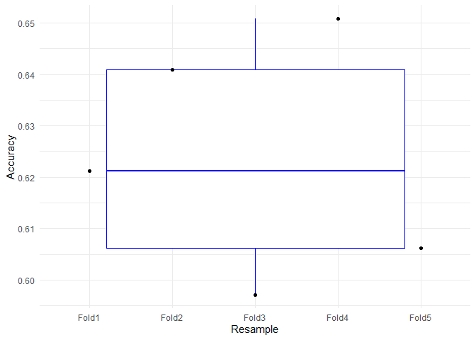

```r
#visualize accuracy scores
ggplot(data=eachfold_NB_uni_5, aes(x=Resample, y=Accuracy, group=1)) +
geom_boxplot(color="blue") +
geom_point() +
theme_minimal()
```

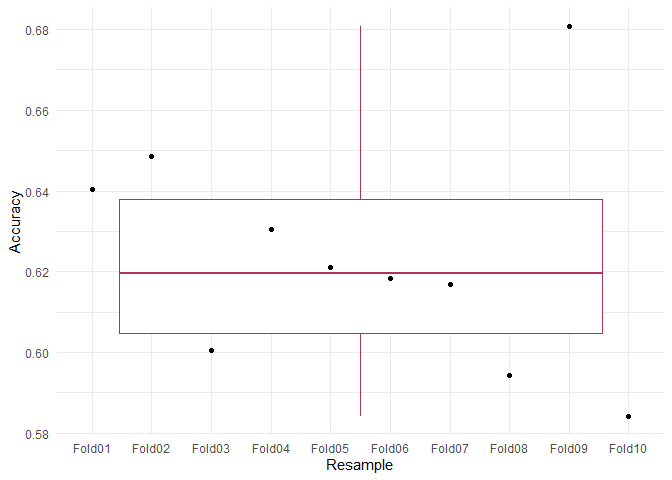

```r
#visualize accuracy scores
ggplot(data=eachfold_NB_uni, aes(x=Resample, y=Accuracy, group=1)) +
geom_boxplot(color="maroon") +
geom_point() +
theme_minimal()
```

```r
cf_df_DT <- data.frame("Group" = factor(rep(c("DT TFIDF", "DT BOW", "DT Uni", "RF TFIDF", "RF BOW", "RF Uni", "NB TFIDF", "NB BOW", "NB Uni"), each = 3)),
                    "Class" = factor(rep(c("negative", "neutral", "positive"), times = 3)),
                    "Spec" = c(cf_DT_tfidf_loo$byClass[,1], cf_DT_tfidf_5$byClass[,1], cf_DT_tfidf$byClass[,1],
                               cf_RF_tfidf_loo$byClass[,1], cf_DT_tfidf_5$byClass[,1], cf_DT_tfidf$byClass[,1],
                               cf_NB_tfidf_loo$byClass[,1], cf_NB_tfidf_5$byClass[,1], cf_NB_tfidf$byClass[,1]),
                    "Sens" = c(cf_DT_tfidf_loo$byClass[,2], cf_DT_tfidf_5$byClass[,2], cf_DT_tfidf$byClass[,2],
                               cf_RF_tfidf_loo$byClass[,2], cf_RF_tfidf_5$byClass[,2], cf_RF_tfidf$byClass[,2],
                               cf_NB_tfidf_loo$byClass[,2], cf_NB_tfidf_5$byClass[,2], cf_NB_tfidf$byClass[,2]))

#specificity
spec_DT <- ggplot(cf_df_DT, aes(y=Spec, x=Group, fill = Class)) +
    geom_bar(position="dodge", stat="identity") +
    geom_text(aes(label=(round(Spec, digits = 3))), position = position_dodge(width= 1))

#sensitivity
sens_DT <- ggplot(cf_df_DT, aes(y=Sens, x=Group, fill = Class)) +
    geom_bar(position="dodge", stat="identity") +
    geom_text(aes(label=(round(Spec, digits = 3))), position = position_dodge(width= 1))
```

### Mean testing of fold accuracy scores

```r
acc_5_fold <- c(eachfold_DT_tfidf_5$Accuracy, eachfold_DT_bow_5$Accuracy, eachfold_DT_uni_5$Accuracy, eachfold_RF_tfidf_5$Accuracy, eachfold_RF_bow_5$Accuracy, eachfold_RF_uni_5$Accuracy,
eachfold_NB_tfidf_5$Accuracy, eachfold_NB_bow_5$Accuracy, eachfold_NB_uni_5$Accuracy)

acc_5_fold_df <- data.frame("Group" = factor(rep(c("DT TFIDF", "DT BOW", "DT Uni", "RF TFIDF", "RF BOW", "RF Uni", "NB TFIDF", "NB BOW", "NB Uni"), each = 5)), "Accuracy" = acc_5_fold)

shapiro.test(acc_5_fold_df$Accuracy)
```

```
##
##  Shapiro-Wilk normality test
##
## data:  acc_5_fold_df$Accuracy
## W = 0.90844, p-value = 0.001754
```

```r
kruskal.test(Accuracy ~ Group, data = acc_5_fold_df)
```

```
##
##  Kruskal-Wallis rank sum test
##
## data:  Accuracy by Group
## Kruskal-Wallis chi-squared = 36.688, df = 8, p-value = 1.313e-05
```

```r
acc_10_fold <- c(eachfold_DT_tfidf$Accuracy, eachfold_DT_bow$Accuracy, eachfold_DT_uni$Accuracy, eachfold_RF_tfidf$Accuracy, eachfold_RF_bow$Accuracy, eachfold_RF_uni$Accuracy, eachfold_NB_tfidf$Accuracy, eachfold_NB_bow$Accuracy, eachfold_NB_uni$Accuracy)

acc_10_fold_df <- data.frame("Group" = factor(rep(c("DT TFIDF", "DT BOW", "DT Uni", "RF TFIDF", "RF BOW", "RF Uni", "NB TFIDF", "NB BOW", "NB Uni"), each = 10)), "Accuracy" = acc_10_fold)

shapiro.test(acc_10_fold_df$Accuracy)
```

```
##
##  Shapiro-Wilk normality test
##
## data:  acc_10_fold_df$Accuracy
## W = 0.919, p-value = 3.197e-05
```

```r
kruskal.test(Accuracy ~ Group, data = acc_10_fold_df)
```

```
##
##  Kruskal-Wallis rank sum test
##
## data:  Accuracy by Group
## Kruskal-Wallis chi-squared = 72.673, df = 8, p-value = 1.44e-12
```

### (Added tests)

```r
Bigramtokenizer <- function(x) {
        unlist(lapply(ngrams(words(x), 2), paste, collapse = " "), use.names = FALSE)}

# bigram dtm
tweets_dtm_bi <- DocumentTermMatrix(tweets_corpus,control = list(tokenize = Bigramtokenizer))

tweets_m_bi <- as.matrix(tweets_dtm_uni)
dim(tweets_m_uni)
```

```
## [1] 7363  138
```

```r
# Display a subset of the matrix
tweets_m_bi[14:28, 10:15]
```

```
##     Terms
## Docs can contact high intern minut say
##   14   0       0    0      0     0   0
##   15   0       0    0      0     0   0
##   16   0       0    0      0     0   0
##   17   0       0    0      0     0   0
##   18   0       0    0      0     0   0
##   19   0       0    0      0     0   0
##   20   1       0    0      0     0   0
##   21   0       0    0      0     0   0
##   22   0       0    0      0     0   0
##   23   1       0    0      0     0   0
##   24   0       0    0      0     0   0
##   25   0       0    0      0     0   0
##   26   0       0    0      0     0   0
##   27   0       0    0      0     0   0
##   28   0       0    0      0     0   0
```

```r
# Reduce the matrix by removing the low frequency terms
tweets_dtm_bi_sparse <- removeSparseTerms(tweets_dtm_uni, 0.99)
tweets_dtm_bi_sparse
```

```
## <<DocumentTermMatrix (documents: 7363, terms: 138)>>
## Non-/sparse entries: 26786/989308
## Sparsity           : 97%
## Maximal term length: 8
## Weighting          : term frequency (tf)
```

```r
tweets_m_bi <- as.matrix(tweets_dtm_uni_sparse)
dim(tweets_m_uni)
```

```
## [1] 7363  138
```

```r
# Display a subset of the matrix after the low frequency terms were removed
tweets_m_bi[14:28, 10:15]
```

```
##     Terms
## Docs even ever fli just never bag
##   14    0    0   0    0     0   0
##   15    0    0   0    1     0   0
##   16    0    0   0    0     0   0
##   17    0    0   0    0     0   0
##   18    0    1   1    0     0   0
##   19    0    0   0    1     0   1
##   20    0    0   0    0     0   0
##   21    0    0   0    0     0   0
##   22    0    0   0    0     0   0
##   23    0    0   0    0     0   0
##   24    0    0   0    0     0   0
##   25    0    0   0    0     0   0
##   26    0    0   0    0     0   0
##   27    0    0   0    0     0   0
##   28    0    0   0    0     0   0
```

```r
m_bi <- as.data.frame(tweets_m_bi)
colnames(m_bi) <- make.names(colnames(m_bi))
m_bi$class = twitter_balanced$airline_sentiment
```

```r
set.seed(577)
split_bi = sample.split(m_bi$class, SplitRatio = 0.7)
train_bi = subset(m_bi, split_tfidf == TRUE)
test_bi = subset(m_bi, split_tfidf == FALSE)

RF_model_bi <- randomForest(class~., data = train_bi)

predictRF_bi <- predict(RF_model_bi, newdata = test_bi)

confusionMatrix(table(test_bi$class, predictRF_bi)) #evaluation of confusion matrix
```

```
## Confusion Matrix and Statistics
##
##           predictRF_bi
##            negative neutral positive
##   negative      542     146       62
##   neutral       181     472       97
##   positive       84     140      485
##
## Overall Statistics
##
##                Accuracy : 0.6786
##                  95% CI : (0.6587, 0.698)
##     No Information Rate : 0.3653
##     P-Value [Acc > NIR] : < 2.2e-16
##
##                   Kappa : 0.5173
##
##  Mcnemar's Test P-Value : 0.001938
##
## Statistics by Class:
##
##                      Class: negative Class: neutral Class: positive
## Sensitivity                   0.6716         0.6227          0.7531
## Specificity                   0.8516         0.8084          0.8569
## Pos Pred Value                0.7227         0.6293          0.6841
## Neg Pred Value                0.8184         0.8040          0.8940
## Prevalence                    0.3653         0.3431          0.2915
## Detection Rate                0.2454         0.2137          0.2196
## Detection Prevalence          0.3395         0.3395          0.3210
## Balanced Accuracy             0.7616         0.7155          0.8050
```

```r
set.seed(4)
model_RF_bi <- train(
  m_bi[,!names(m_bi) %in% c("class")], m_bi$class, "cforest", controls = cforest_unbiased(ntree = 10),
  trControl = trainControl(method = "cv", number = 10, savePredictions = "final", classProbs = TRUE)
)

model_RF_bi
```

```
## Conditional Inference Random Forest
##
## 7363 samples
##  138 predictor
##    3 classes: 'negative', 'neutral', 'positive'
##
## No pre-processing
## Resampling: Cross-Validated (10 fold)
## Summary of sample sizes: 6627, 6627, 6627, 6627, 6626, 6627, ...
## Resampling results across tuning parameters:
##
##   mtry  Accuracy   Kappa
##     2   0.6509577  0.4751929
##    70   0.6347977  0.4509915
##   138   0.6333006  0.4486814
##
## Accuracy was used to select the optimal model using the largest value.
## The final value used for the model was mtry = 2.
```

```r
#create a confusion matrix for the best fold
confusionMatrix(model_RF_bi$pred[order(model_RF_bi$pred$rowIndex),2], m_bi$class)
```

```
## Confusion Matrix and Statistics
##
##           Reference
## Prediction negative neutral positive
##   negative     1640     519      326
##   neutral       707    1729      613
##   positive      153     252     1424
##
## Overall Statistics
##
##                Accuracy : 0.651
##                  95% CI : (0.6399, 0.6619)
##     No Information Rate : 0.3395
##     P-Value [Acc > NIR] : < 2.2e-16
##
##                   Kappa : 0.4752
##
##  Mcnemar's Test P-Value : < 2.2e-16
##
## Statistics by Class:
##
##                      Class: negative Class: neutral Class: positive
## Sensitivity                   0.6560         0.6916          0.6026
## Specificity                   0.8262         0.7286          0.9190
## Pos Pred Value                0.6600         0.5671          0.7786
## Neg Pred Value                0.8237         0.8213          0.8303
## Prevalence                    0.3395         0.3395          0.3209
## Detection Rate                0.2227         0.2348          0.1934
## Detection Prevalence          0.3375         0.4141          0.2484
## Balanced Accuracy             0.7411         0.7101          0.7608
```

```r
pred_RF_bi <- model_RF_bi$pred
pred_RF_bi$equal <- ifelse(pred_RF_bi$pred == pred_RF_bi$obs, 1, 0)

eachfold_RF_bi <- pred_RF_bi %>%
  group_by(Resample) %>%
  summarise_at(vars(equal),
               list(Accuracy = mean))

eachfold_RF_bi
```

```
## # A tibble: 10 x 2
##    Resample Accuracy
##    <chr>       <dbl>
##  1 Fold01      0.626
##  2 Fold02      0.660
##  3 Fold03      0.649
##  4 Fold04      0.659
##  5 Fold05      0.651
##  6 Fold06      0.654
##  7 Fold07      0.650
##  8 Fold08      0.650
##  9 Fold09      0.668
## 10 Fold10      0.641
```

```r
set.seed(41)
model_RF_bi_50 <- train(
  m_bi[,!names(m_bi) %in% c("class")], m_bi$class, "cforest", controls = cforest_unbiased(ntree = 50),
  trControl = trainControl(method = "cv", number = 10, savePredictions = "final", classProbs = TRUE)
)

model_RF_bi_50
```

```
## Conditional Inference Random Forest
##
## 7363 samples
##  138 predictor
##    3 classes: 'negative', 'neutral', 'positive'
##
## No pre-processing
## Resampling: Cross-Validated (10 fold)
## Summary of sample sizes: 6627, 6626, 6627, 6626, 6626, 6627, ...
## Resampling results across tuning parameters:
##
##   mtry  Accuracy   Kappa
##     2   0.6652130  0.4966811
##    70   0.6368291  0.4540441
##   138   0.6311245  0.4454149
##
## Accuracy was used to select the optimal model using the largest value.
## The final value used for the model was mtry = 2.
```

```r
#create a confusion matrix for the best fold
confusionMatrix(model_RF_bi_50$pred[order(model_RF_bi_50$pred$rowIndex),2], m_bi$class)
```

```
## Confusion Matrix and Statistics
##
##           Reference
## Prediction negative neutral positive
##   negative     1711     512      329
##   neutral       647    1729      576
##   positive      142     259     1458
##
## Overall Statistics
##
##                Accuracy : 0.6652
##                  95% CI : (0.6543, 0.676)
##     No Information Rate : 0.3395
##     P-Value [Acc > NIR] : < 2.2e-16
##
##                   Kappa : 0.4967
##
##  Mcnemar's Test P-Value : < 2.2e-16
##
## Statistics by Class:
##
##                      Class: negative Class: neutral Class: positive
## Sensitivity                   0.6844         0.6916          0.6170
## Specificity                   0.8271         0.7485          0.9198
## Pos Pred Value                0.6705         0.5857          0.7843
## Neg Pred Value                0.8360         0.8252          0.8356
## Prevalence                    0.3395         0.3395          0.3209
## Detection Rate                0.2324         0.2348          0.1980
## Detection Prevalence          0.3466         0.4009          0.2525
## Balanced Accuracy             0.7557         0.7201          0.7684
```

```r
pred_RF_bi_50 <- model_RF_bi_50$pred
pred_RF_bi_50$equal <- ifelse(pred_RF_bi_50$pred == pred_RF_bi_50$obs, 1, 0)

eachfold_RF_bi_50 <- pred_RF_bi_50 %>%
  group_by(Resample) %>%
  summarise_at(vars(equal),
               list(Accuracy = mean))

eachfold_RF_bi_50
```

```
## # A tibble: 10 x 2
##    Resample Accuracy
##    <chr>       <dbl>
##  1 Fold01      0.652
##  2 Fold02      0.670
##  3 Fold03      0.649
##  4 Fold04      0.684
##  5 Fold05      0.678
##  6 Fold06      0.636
##  7 Fold07      0.692
##  8 Fold08      0.670
##  9 Fold09      0.674
## 10 Fold10      0.647
```

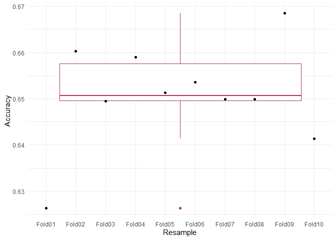

```r
#visualize accuracy scores
ggplot(data=eachfold_RF_bi, aes(x=Resample, y=Accuracy, group=1)) +
  geom_boxplot(color="maroon") +
  geom_point() +
  theme_minimal()
```

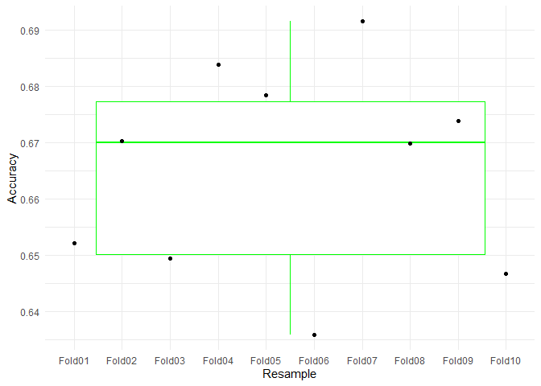

```r
#visualize accuracy scores
ggplot(data=eachfold_RF_bi_50, aes(x=Resample, y=Accuracy, group=1)) +
  geom_boxplot(color="green") +
  geom_point() +
  theme_minimal()
```